# 1 Introduction

#### NDK_sendto – Transmit Data on a Socket to Designated Destination

```c
int NDK_sendto(SOCKET          s,
               void            *pbuf,
               int             size,
               int             flags,
               struct sockaddr *pName,
               int             len);
```

**Parameters**

- s: Socket
- pbuf: Data buffer holding data to transmit
- size: Size of data
- flags: Option flags
- pName: Pointer to name (address) of destination
- len: Size of data pointed to by pName

**Return Value** If it succeeds, the function returns the number of bytes sent. Otherwise, a value of -1 is returned and the function *fdError()* can be called to determine the error:

- EBADF: The file descriptor (socket) is invalid.
- EHOSTUNREACH: The remote host was unreachable.
- EMSGSIZE: The specified size exceeds the limit of the underlying protocol.
- ENOBUFS: Memory allocation failure while attempting to send data.
- ENOTSOCK: The file descriptor does not reference a socket.
- ENOTCONN: The socket is connection oriented and not connected.
- ESHUTDOWN: The socket has been shut down for writes.
- ETIMEDOUT: The socket connection was dropped due to protocol layer timeout.
- EWOULDBLOCK: The socket is specified as non-blocking, or the timeout has expired.

**Description** The *NDK_sendto()* function attempts to send data on a socket to a specified destination. It is used on unconnected, non-connection oriented sockets only (see *NDK_connect()* ). The data to send is contained in the buffer specified by pbuf, with a length specified by size. The options in flags can be used to change the default behavior of the operation.

The argument *pName* is a pointer to the address of the destination entity as known to the communications layer. The domain in which the communication is occurring determines the exact format of the *pName* parameter. The *len* parameter should contain the size of name, which is sizeof(struct sockaddr).

The function returns the length of the data transmitted on successful completion.

For a datagram type socket, the send operation always copies one packet’s worth of data. If the buffer size is too large to be transmitted in a single packet, an error code of EMSGSIZE is returned.

The select call (*fdSelect()*) may be used to determine when the socket is able to write.

The flags argument to an *NDK_sendto()* call is formed by combining one or more of the following flags:

- MSG_OOB: sends out-of-band data on sockets that support this notion (e.g., SOCK_STREAM); the underlying protocol must also support out-of-band data.
- MSG_EOR: indicates a record mark for protocols that support the concept.
- MSG_EOF: Requests that the sender side of a socket be shut down, and that an appropriate indication be sent at the end of the specified data; this flag is only implemented for SOCK_STREAM sockets in the AF_INET protocol family, and implements Transaction TCP.
- MSG_DONTROUTE: Specifies that the packet should not be routed, but sent only using the ARP table entries.

> **NOTE:** The native operation of the socket *NDK_sendto* operation is to connect, sendto, and disconnect. Sockets that are not bound to a local IP or local port would have an ephemeral port selected every time in order to override this behavior and to ensure that the ephemeral port is not selected every time it is recommended that customers do an *NDK_bind()* to port 0. This selects the first free port not in use and all subsequent communication uses the same port.

#### NDK_setsockopt – Set the Value of a Socket Option Parameter

```c
int NDK_setsockopt(SOCKET s,
                   int    level,
                   int    op,
                   void   *pbuf,
                   int    bufsize);
```

**Parameters**

- s: Socket
- level: Option level (SOL_SOCKET, IPPROTO_IP, IPPROTO_TCP)
- op: Socket option to set
- pbuf: Pointer to memory buffer
- bufsize: Size of memory buffer pointed to by pbuf

**Return Value** If it succeeds, the function returns 0. Otherwise, a value of -1 is returned and the function *fdError()* can be called to determine the error:

- EBADF: The file descriptor (socket) is invalid.
- ENOTSOCK: The file descriptor does not reference a socket.
- EINVAL: bufsize argument is invalid.
- EDOM: pbuf argument is invalid for the selected option.
- ENOMEM: The selected option could not allocate the memory needed.

**Description** The *NDK_setsockopt()* function sets option values associated with a socket. Options may exist at multiple protocol levels; they are always present at the uppermost socket level.

When manipulating socket options, the level at which the option resides and the name of the option must be specified. To manipulate options at the socket level, level is specified as SOL_SOCKET. To manipulate options at any other level, the protocol number of the appropriate protocol controlling the option is supplied. In this implementation, only SOL_SOCKET, IPPROTO_IP, and IPPROTO_TCP are supported.

The parameters *pbuf* and *bufsize* identify a buffer that holds the value for the specified option.

Most socket-level options utilize an int parameter for *pbuf*. SO_LINGER uses a struct linger parameter, which specifies the desired state of the option and the linger interval; see the example provided for *NDK_getsockopt()*. SO_SNDTIMEO and SO_RCVTIMEO use a struct timeval parameter. The IP-level options IP_ADD_MEMBERSHIP and IP_DROP_MEMBERSHIP accept a struct ip_mreq parameter.

The socket options supported for *NDK_setsockopt()* are the same as defined for *NDK_getsockopt()*, with the exception of SO_TYPE and SO_ERROR, which cannot be set.

Please see the description of *NDK_getsockopt()* for a list of socket options.

> **NOTE:** The SO_SNDBUF and SO_RCVBUF options can only be set if there is no transmit or receive data pending at the socket. In general, the buffer sizes should only be configured before the socket is bound or connected. Buffer sizes set on listen sockets will propagate to spawned accept sockets.

#### NDK_shutdown – Close One Half of a Connected Socket

```c
int NDK_shutdown(SOCKET s,
                 int    how);
```

**Parameters**

- s: Socket
- how: Manner of shut down

**Return Value** If it succeeds, the function returns 0. Otherwise, a value of -1 is returned and the function *fdError()* can be called to determine the error:

- EBADF: The file descriptor (socket) is invalid.
- ENOTSOCK: The file descriptor does not reference a socket.
- ENOTCONN: The specified socket is not connected.

**Description** The *NDK_shutdown()* function causes all or part of a full-duplex connection on the socket associated with a socket to be shut down. If *how* is SHUT_RD (0), further receives will be disallowed. If *how* is SHUT_WR (1), further sends will be disallowed. If *how* is SHUT_RDWR (2), further sends and receives will be disallowed.

#### NDK_socket – Create a Socket

```c
SOCKET NDK_socket(int domain,
                  int type,
                  int protocol);
```

**Parameters**

- domain: Socket domain (AF_INET or AF_INET6)
- type: Socket type (SOCK_DGRAM, SOCK_STREAM, SOCK_RAW)
- protocol: Socket protocol (Normally IPPROTO_TCP or IPPROTO_UDP, but can be anything when type is set to SOCK_RAW)

**Return Value** If it succeeds, the function returns a file descriptor representing the socket. Otherwise, a value of INVALID_SOCKET is returned and the function *fdError()* can be called to determine the error:

- EPFNOSUPPORT: The specified domain was not AF_INET or AF_INET6.
- EPROTOTYPE: The *type* parameter does not support the *protocol* parameter.
- ESOCKTNOSUPPORT: The specified socket type is not supported.
- ENOMEM: Memory allocation error allocating socket buffers.
- EMFILE: The descriptor table is full.

**Description** The *NDK_socket()* function creates a socket, an endpoint for communication and returns the socket in the form of a file descriptor.

The *domain* parameter specifies a communications domain within which communication will take place; this selects the protocol/address family that should be used. This will always be AF_INET or AF_INET6 in this implementation.

The socket type parameter specifies the semantics of communication. The defined types are:

- SOCK_STREAM: Provides sequenced, reliable, two-way connection based byte streams. An out-of-band data transmission mechanism is supported.
- SOCK_STREAMNC: Identical to SOCK_STREAM except that received data is not coalesced into a receive holding buffer. This eliminates one or two receive data copies (depending on which *NDK_recv()* socket function is used), but has the potential of tying up multiple data packets. It should only be used when the socket is to receive data in large bursts. Out-of-band data is supported, but only when the traditional *NDK_recv()* socket calls are used.
- SOCK_DGRAM: Supports datagrams - connectionless, unreliable messages of a fixed (typically small) maximum length.
- SOCK_RAW: Similar to SOCK_DGRAM, only allows the use of any protocol that must be manually constructed in each datagram by the programmer.

The *protocol* parameter specifies a particular protocol to be used with the socket. In this implementation of the stack, SOCK_STREAM must use IPPROTO_TCP, SOCK_DGRAM must use IPPROTO_UDP, and SOCK_RAW is unrestricted. To remain compatible with the industry, this parameter can be set to NULL on SOCK_STREAM or SOCK_DGRAM.

## 3.4 Raw Ethernet Sockets Programming Interface

Raw Ethernet sockets are a special type of sockets that allow an application to send and receive entire Ethernet packets without any intermediate processing by the stack, like stripping off headers, checksum calculations, etc., that are typically done for IPv4, IPv6 sockets. These sockets are expected to be used by applications that have very definite performance requirements and need ultimate control over packet processing. The Raw Ethernet sockets have both *no-copy* send and receive APIs. This facilitates the application’s performance requirements even further by reducing any overhead on the send or receive data paths due to memory allocation and copying. A corresponding *Raw Ethernet Module* has also been added to the core NDK stack that interfaces with the NIMU layer to send/receive data. For more details on the Raw Ethernet module, see Section A.15 of this document.

### 3.4.1 Function Overview

The following is a complete list of socket APIs implemented for the Raw Ethernet socket family (AF_RAWETH).

[output not shown]

### 3.4.2 Raw Ethernet Sockets API Functions

This section describes the socket APIs listed before in detail and in particular when used with AF_RAWETH family sockets.

#### NDK_socket – Create a raw Ethernet socket.

```c
SOCKET NDK_socket( int domain,
                   int type,
                   int protocol );
```

**Parameters**

- domain: Socket domain (AF_RAWETH)
- type: Socket type (SOCK_RAWETH)
- protocol: Socket protocol (can be set to any custom value other than the well-known types: IP (0x800), IPv6 (0x86DD), VLAN (0x8100), PPPoE Control (0x8863), PPPoE Data (0x8864) is acceptable)

**Return Value** If it succeeds, the function returns a file descriptor representing the socket. Otherwise, a value of INVALID_SOCKET is returned and the function *fdError()* can be called to determine the error:

- EPFNOSUPPORT: The specified domain was none of the supported families, i.e., AF_INET, AF_INET6, AF_RAWETH.
- EINVAL: The protocol parameter supplied is not valid. IP (0x800), IPv6 (0x86DD), VLAN (0x8100), PPPoE Control (0x8863), PPPoE Data (0x8864) are not valid values for the protocol argument.
- ESOCKTNOSUPPORT: The specified socket type is not supported for this protocol.
- ENOMEM: Memory allocation error allocating socket buffers.
- EMFILE: The descriptor table is full.

**Description** The *NDK_socket()* function creates a socket, an endpoint for communication and returns the socket in the form of a file descriptor. The *domain* parameter specifies a communications domain within which communication will take place; this selects the protocol/address family that should be used. To create a raw Ethernet socket, the domain must be specified as AF_RAWETH. The socket type parameter specifies the semantics of communication. For raw Ethernet sockets, this parameter must be set to SOCK_RAWETH. The protocol parameter specifies the protocol to be used for the socket. This can be set to any custom protocol type for a raw Ethernet socket. Standard protocol types like IP (0x800), IPv6 (0x86DD), VLAN (0x8100), PPPoE Control (0x8863), PPPoE Data (0x8864) must not be used here for protocol parameter.

#### NDK_shutdown – Close one half of a connected socket.

```c
int NDK_shutdown( SOCKET s,
                  int    how );
```

**Parameters**

- s: Socket
- how: Manner of shut down

**Return Value** If it succeeds, the function returns 0. Otherwise, a value of -1 is returned and the function *fdError()* can be called to determine the error:

- EBADF: The file descriptor (socket) is invalid.
- ENOTSOCK: The file descriptor does not reference a socket.

**Description** The *NDK_shutdown()* function causes all or part of a full-duplex connection on the socket associated with a socket to be shut down. If *how* is SHUT_RD (0), further receives will be disallowed. If *how* is SHUT_WR (1), further sends will be disallowed. If *how* is SHUT_RDWR (2), further sends and receives will be disallowed.

#### NDK_getsockopt – Get the value of a socket option.

```c
int NDK_getsockopt(SOCKET s,
                   int    level,
                   int    op,
                   void   *pbuf,
                   int    *pbufsize);
```

**Parameters**

- s: Socket
- level: Option level (SOL_SOCKET only for AF_RAWETH sockets)
- op: Socket option to get
- pbuf: Pointer to memory buffer
- pbufsize: Pointer to size of memory buffer

**Return Value** If it succeeds, the function returns 0. Otherwise, a value of -1 is returned and the function *fdError()* can be called to determine the error:

- EBADF: The file descriptor (socket) is invalid.
- ENOTSOCK: The file descriptor does not reference a socket.
- EINVAL: Buffer arguments are invalid.

**Description** The *NDK_getsockopt()* function returns the options associated with a socket. Options are always present at the uppermost socket level (SOL_SOCKET) for raw Ethernet sockets. When manipulating socket options, the level at which the option resides and the name of the option must be specified. The parameters *pbuf* and *pbufsize* identify a buffer in which the value for the requested option(s) are to be returned. *pbufsize* is a value-result parameter, initially containing the size of the buffer pointed to by *pbuf*, and modified on return to indicate the actual size of the value returned.

The following socket (SOL_SOCKET) level options are recognized for raw Ethernet sockets:

- SO_IFDEVICE: Specifies a uint32_t index (1 to *n*) of the designated interface for sending and receiving raw Ethernet packets.

> **NOTE:** The SO_IFDEVICE option must be configured to successfully use a raw Ethernet socket for communication.
- SO_PRIORITY: Specifies a unit value (0 to 7) configured as the priority to be marked on all flowing packets using this socket. This priority can be used by the Ethernet driver in turn to differentiate between packets and apply any desired QoS scheme. It can be also used by a driver/application to map the priority to certain transmission properties like the EMAC channel number on which the packets are to be transmitted. Only unsigned integer values between 0 to 7 are acceptable values for this field. When a value of 0xFFF is set to this option, it resets the priority back to its default value.
- SO_RCVTIMEO: Is an option to set a timeout value for input operations. It accepts a struct timeval parameter with the number of seconds and microseconds used to limit waits for input operations to complete. This timer is restarted each time additional data are received by the protocol, and therefore, the limit is in effect an inactivity timer. If a receive operation has been blocked for this much time without receiving additional data, it returns with a short count or with the error EWOULDBLOCK if no data were received.
- SO_SNDBUF: Buffer size for output
- SO_RCVBUF: Buffer size for input
- SO_RCVLOWAT: Is an option to set the minimum size of data in bytes for input operations. The default value for SO_RCVLOWAT is 1. Receive calls may still return less than the amount specified by SO_RCVLOWAT or the amount requested if an error occurs.
- SO_ERROR: Returns any pending error on the socket and clears the error status. It may be used to check for any asynchronous errors.
- SO_TYPE: Returns the type of the socket. Always returns SOCK_RAWETH for raw Ethernet sockets.

> **NOTE:** Options like SO_SNDWAT, SO_SNDTIMEO, etc., are not supported for raw Ethernet sockets, since there is no buffering on the send path and the operation is synchronous; i.e., once *NDK_send()*/*NDK_sendnc()* APIs are invoked for raw Ethernet sockets, these calls actually return only after enqueuing the data in the driver queue. Hence, no buffering or timeouts are required.

#### NDK_setsockopt – Set the value of a socket option.

```c
int NDK_setsockopt( SOCKET s,
                    int    level,
                    int    op,
                    void   *pbuf,
                    int    bufsize);
```

**Parameters**

- s: Socket
- level: Option level (SOL_SOCKET only for AF_RAWETH sockets)
- op: Socket option to set
- pbuf: Pointer to memory buffer
- bufsize: Size of memory buffer pointed to by pbuf

**Return Value** If it succeeds, the function returns 0. Otherwise, a value of -1 is returned and the function *fdError()* can be called to determine the error:

- EBADF: The file descriptor (socket) is invalid.
- ENOTSOCK: The file descriptor does not reference a socket.
- EINVAL: bufsize argument is invalid.
- EDOM: pbuf argument is invalid for the selected option.
- ENOMEM: The selected option could not allocate the memory needed.

**Description** The *NDK_setsockopt()* function sets option values associated with a socket. Options are always present at the uppermost socket level (SOL_SOCKET) for raw Ethernet sockets. When manipulating socket options, the level at which the option resides and the name of the option must be specified. The parameters *pbuf* and *bufsize* identify a buffer that holds the value for the specified option. Most socket-level options utilize an int parameter for *pbuf.*

The socket options supported for *NDK_setsockopt()* are the same as the ones specified in the *NDK_getsockopt()* API.

#### NDK_send – Transmit raw Ethernet data using a socket.

```c
int NDK_send( SOCKET s,
              void   *pbuf,
              int    size,
              int    flags );
```

**Parameters**

- s: Socket
- pbuf: Data buffer holding data to transmit
- size: Size of data
- flags: Option flags

**Return Value** If it succeeds, the function returns the number of bytes sent. Otherwise, a value of -1 is returned and the function *fdError()* can be called to determine the error:

- ENOTSOCK: The file descriptor does not reference a socket.
- EINVAL: The input is invalid.
- ENOBUFS: Memory allocation failure while attempting to send data.
- ESHUTDOWN: The socket has been shut down for writes.
- EMSGSIZE: The size of the data being sent exceeds the MTU of the interface or the Maximum Transmit buffer size configured using SO_SNDBUF option, whichever is the smaller value of the two.
- ENXIO: No egress interface specified for this socket to send out data. Use SO_IFDEVICE socket option and specify an interface before retrying to send out data using this socket.

**Description** The *NDK_send()* function attempts to send data on a socket. The data to send is contained in the buffer specified by pbuf, with a length specified by size. The options in flags can be used to change the default behavior of the operation. No flag options are defined for raw Ethernet sockets. The function returns the length of the data transmitted on successful completion.

The data buffer specified here is allocated and freed up by the application itself. The packet buffer is copied over to the packet allocated on the transmit path by the Raw Ethernet module and hence the application buffer (pbuf) freeing is the responsibility of the application when this API returns. Based on the socket handle specified to this call, the raw Ethernet module retrieves the socket priority and device on which this packet needs to be transmitted and does the needful to transmit the data. All packets transmitted using the specified socket would inherit their priority from the socket.

The format of the data buffer sent as input to this function is shown as follows:

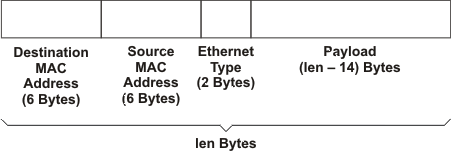

#### NDK_getsendncbuff – Retrieve handle to buffer application can fill with raw Ethernet data to send.

```c
int NDK_getsendncbuff( SOCKET   s,
                       uint32_t bufSize,
                       void     **phBuf,
                       void     **phPkt );
```

**Parameters**

- s: Socket
- bufSize: Size of data buffer to allocate
- phbuf: Pointer to send data buffer pointer
- phPkt: Pointer to packet buffer handle

**Return Value** If it succeeds, the function returns 0. Also, the phbuf and phPkt pointers are filled in with valid pointers to the data and packet buffers just allocated. Otherwise, a value of -1 is returned and the function *fdError()* can be called to determine the error:

- ENOBUFS: Out of memory. Couldn’t allocate memory required for the packet and data buffer.
- EMSGSIZE: The size of the data buffer requested exceeds the MTU of the interface or the Maximum Transmit buffer size configured using SO_SNDBUF option, whichever is the smaller value of the two on the specified socket.

**Description** This API needs to be called by the raw Ethernet application to obtain a buffer handle to use to transmit data without copy using the *NDK_sendnc()* API. This function ensures that bufSize byte memory is allocated for the raw Ethernet data buffer. It also allocates memory for the packet to hold this data buffer. The application can fill the required data in the buffer just obtained and needs to send both the data buffer and the packet pointers to *NDK_sendnc()* API to finally send out the packet. This packet and the data buffer are freed by the Ethernet driver once the transmit completes successfully. However, if the application would like to free up the buffer obtained because of some error it encountered during send process, it would have to use the *NDK_sendncfree* API and specify the packet buffer handle as a parameter and both the data buffer and packet buffer will be freed up.

#### NDK_sendnc – Send data out on the socket without any copy on transmit path.

```c
int NDK_sendnc( SOCKET s,
                void   *pbuf,
                int    size,
                void   *hPkt,
                int    flags );
```

**Parameters**

- s: Socket
- pbuf: Pointer to send data buffer
- hPkt: Packet buffer handle obtained from the *NDK_getsendncbuff()* API
- flags: Option flags

**Return Value** If it succeeds, the function returns number of bytes transmitted. Otherwise, a value of -1 is returned, and the function *fdError()* can be called to determine the error:

- EINVAL: The input is invalid
- ESHUTDOWN: The socket has been shut down for writes
- ENOTSOCK: The file descriptor does not reference a socket
- ENXIO: No egress interface specified for this socket to send out data. Use SO_IFDEVICE socket option and specify an interface before retrying to send out data using this socket.

**Description** The *NDK_sendnc()* API function attempts to send the data buffer and packet specified using the raw Ethernet socket handle provided. It doesn’t make any copies of the data on the transmit path and, therefore, provides a significant performance gain to the application using it. The buffer pointer and the packet handle must be obtained using the *NDK_getsendncbuff()* API before this function is called. The size of data buffer specified as input to this function must not exceed the size of buffer allocated using the *NDK_getsendncbuff()* API. No option flags are defined at this time for this API. This packet and the data buffer are freed by the Ethernet driver once the transmit completes successfully. However, If an error is returned from this API, the application is responsible for freeing up the packet and data buffers obtained earlier from the *NDK_getsendncbuff()* API by calling the *NDK_sendncfree()* API with the packet handle as input.

The format of the data buffer sent as input to this function is expected to be the following:

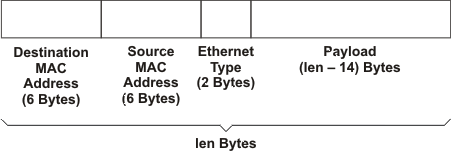

#### NDK_sendncfree – Free the packet and data buffers obtained using the NDK_getsendncbuff() API.

```c
void NDK_sendncfree( void *hFrag );
```

**Parameters**

- hFrag: Handle to send buffer to free

**Return Value** None

**Description** The *NDK_sendncfree()* function frees the packet and data buffer obtained from calling the *NDK_getsendncbuff()* API. The calling parameter, *hFrag*, is the handle of the packet buffer to free (not the pointer to the buffer handle).

#### NDK_recvnc – Receive data from a socket without buffer copy

```c
int NDK_recvnc( SOCKET s,
                void   **ppbuf,
                int    flags,
                void   **phBuffer );
```

**Parameters**

- s: Socket
- ppbuf: Pointer to receive data buffer pointer
- flags: Option flags
- phBuffer: Pointer to receive buffer handle

**Return Value** If it succeeds, the function returns the number of bytes received. Otherwise, a value of -1 is returned and the function *fdError()* can be called to determine the error:

- EBADF: The file descriptor (socket) is invalid
- EINVAL: Attempt to read (or calling arguments) invalid for this socket
- ENOTSOCK: The file descriptor does not reference a socket
- EWOULDBLOCK: The receive timeout configured on the socket has expired and no data received so far.
- ENXIO: No egress interface specified for this socket to receive from. Use SO_IFDEVICE socket option and specify an interface before retrying to receive data using this socket.

**Description** The *NDK_recvnc()* function attempts to receive a data buffer from a socket. A pointer to the data buffer is returned in *ppbuf*. A system handle used to free the buffer is returned in *phBuffer*. Both of these pointers must be valid. The options in flags can be used to change the default behavior of the operation. No flags are defined for raw Ethernet sockets. The function returns the length of the message on successful completion. The receive operation always returns one packet buffer. The caller has no control over the size of the data returned in this buffer. If no messages are available at the socket, this call waits for a message to arrive for the receive timeout specified on this socket. If no timeout is specified this call blocks forever waiting for data to arrive on the socket. The function returns the data buffer available. When the caller no longer needs the data buffer, it is returned to the system by calling *NDK_recvncfree()*. Repeated failure to free buffers eventually causes the stack to stop receiving data.

> **NOTE:** Take care when using the *NDK_recvnc()* API, because packet buffers come from the driver; there may be a limited supply available. The packet buffers must be promptly freed up by the application once processing is complete.

#### NDK_recvncfree – Return a data buffer obtained from a no-copy receive operation

```c
void NDK_recvncfree(void *hBuffer);
```

**Parameters**

- hBuffer: Handle to receive buffer to free

**Return Value** None

**Description** The *NDK_recvncfree()* function frees a data buffer obtained from calling *NDK_recvnc()*. The calling parameter *hBuffer* is the handle of the buffer to free (not the pointer to the buffer).

## 3.5 Full Duplex Pipes Programming Interface

Although sockets can be used for inter-task communications, it is not the most efficient method. The stack provides a second data communications model called pipes, which allow for local connection oriented communications.

A pipe is a full duplex connection oriented file descriptor. When a pipe is created, both ends of the pipe are returned to the caller as file descriptors.

Communication is performed using the standard file and sockets API functions. All the file descriptor functions are supported with pipes: *fdSelect()*, *fdClose()*, *fdError()*.

Also, socket functions *NDK_send()* and *NDK_recv()* write and read data through the pipe. Both functions also support the following standard sockets message flags when using pipes:

- MSG_PEEK: Examine data but do not consume it.
- MSG_DONTWAIT: Do not block on send/recv operation (by default, pipe operations always block).

Pipes are connection oriented, thus, when one end closes, the other end is altered by an error return from *NDK_send()* or *NDK_recv()*. It is therefore possible to make a blocking call on *NDK_recv()* without concern that the function will be deadlocked if the other end terminates the connection.

### 3.5.1 Pipe API Functions

Because pipes share file descriptor and IO functions with sockets, the only pipe oriented function is the creation of the connected pair.

#### NDK_pipe – Create a Full Duplex Pipe

```c
int NDK_pipe( void **pfd1,
              void **pfd2);
```

**Parameters**

- pfd1: Pointer to file descriptor to first end of pipe.
- pfd2: Pointer to file descriptor to second end of pipe.

**Return Value** Returns zero on success or -1 on error. A more detailed error code can be found by calling *fdError()*.

**Description** Creates a pre-connected full duplex pipe. The returned file descriptors can be used with all the fd file descriptor functions, as well as the *NDK_send()* and *NDK_recv()* socket functions.

Pipes are connection oriented, so like TCP, a read or write call can return ENOTCONN when the connection is broken by one side or the other.

> **NOTE:** Both file descriptors must be closed to correctly close down (and free) a pipe.

## 3.6 Internet Group Management Protocol (IGMP)

Internet Group Management Protocol (IGMP) is designed to help routers in routing IP multicast traffic. Each router can have multiple ports, and it is inefficient for the router to replicate every IP multicast packet out of each active port. Using the IGMP protocol, the multicast router is able to keep track of which IP multicast addresses need to be routed to each individual port. This allows the router to limit IP multicast transmission to only those ports that require the multicast traffic.

The IGMP protocol assumes a client/server relationship between endpoints. The IGMP server is run by the multicast router to get IP multicast information about all the client on each of its individual ports. The IGMP client is only concerned with communicating its own multicast requirements to the local IGMP server, so that it will get the IP multicast packets that it requires.

The NDK does not support IP multicast routing, so there is no need to use IGMP in server mode. However, the software does support IGMP client operation.

The IGMP client module indicates to the IGMP server which multicast IP addresses that the client needs to receive. The IGMP API will also maintain the Ethernet multicast MAC address list at the Ethernet driver level.

An application can join or leave a multicast group using the well-known *NDK_setsockopt()* API. To do this, use the *NDK_setsockopt()* and *NDK_getsockopt()* APIs with the IP_ADD_MEMBERSHIP and IP_DROP_MEMBERSHIP options. For more details on options for joining or leaving a multicast group, see getsockopt() and setsockopt().

# 4 Configuration and Initialization

This chapter discusses the Configuration Manager API, which is the recommended method for configuring your application. In addition, this chapter discusses the initialization sequence for the NDK.

## 4.1 Configuration Methods

There are two ways to configure an application’s use of NDK modules:

- The **Configuration Manager API** is a collection of functions to help you create and manipulate a configuration. This chapter describes the Configuration Manager API and its effects on the configuration database.
- The **XGCONF configuration tool** within CCStudio can configure an application’s use of NDK modules. Graphical displays let you enable and set properties as needed, and context-sensitive help provides information about individual fields. This configuration method cannot be used with FreeRTOS. XGCONF is a configuration tool used to configure the TI-RTOS Kernel (previously called SYS/BIOS). The same configuration in one project can configure both NDK and TI-RTOS modules and objects.

  To open XGCONF in CCStudio, double-click the *.cfg file in your application’s project. Alternatively, you can edit the* .cfg file in your TI-RTOS project with a text editor. See the steps in the *TI Network Developer’s Kit (NDK) User’s Guide.* (SPRU523) for using XGCONF with the NDK. For more about using XGCONF, see Chapter 2 of the *TI-RTOS Kernel User’s Guide* ([SPRUEX3](http://www.ti.com/lit/pdf/spruex3)).

Internally, the XGCONF configuration tool generates C code that uses the Configuration Manager API to update the configuration database.

> **NOTE:** You should not mix configuration methods. If you have NDK applications that use the API-based configuration method, you should either continue to use that method or convert the configuration entirely to an *.cfg file configuration using XGCONF. If a project uses both methods, there will be conflicts between the two configurations.

## 4.2 Configuration Manager API

The Configuration Manager is a collection of API functions to help you create and manipulate a configuration. The manager API is independent of the configuration specification.

The configuration is arranged as a database with a master key (called *Tag*) that defines the class of configuration item. A second key (called *Item*) determines the sub-item type in the *tag* class. For each *tag* and *item*, there can be multiple instances. Items can be further distinguished by their *instance* value.

The configuration is based on an active database. That is, any change to the database can cause an immediate reaction in the system. For example, if a route is added to the configuration, it is added to the system route table. If the route is then removed from the configuration, it is removed from the system route table.

To facilitate the active procession of configuration changes in a generic fashion, the configuration API allows the installation of service provider callback functions that are called to handle specific *tag* values in the configuration.

Configurations can be set active or inactive. When a configuration is active, any change to the configuration results in a change in the system. When a configuration is inactive, it behaves like a standard database. Part of the main initialization sequence is to make the system configuration active, and then inactive when shutting down.

Both the configurations and configuration entries are referenced by a generic handle. Configuration functions (named as *CfgXxx()*) take a configuration handle parameter, while configuration entry functions (name as *CfgEntryXxx()*) take a configuration entry handle parameter. These handles are not interchangeable.

Configuration entry handles are *referenced*. This means that each handle contains an internal reference count so that the handle is not destroyed by one task while another task expects it to stay valid. Functions that return a configuration entry handle supply a referenced handle in that its reference count has already been incremented for the caller. The caller can hold this handle indefinitely, but should dereference it when it is through. There are three calls that dereference a configuration entry handle. These are: *CfgRemoveEntry()*, *CfgGetNextEntry()*, and most simply *CfgEntryDeRef()*. See individual function descriptions for more information.

The PPP module in the stack library and several modules in the NETTOOLS library make use of a *default* configuration to store and search for data. The default configuration is accessed by passing in a NULL configuration handle to any function that takes the *hCfg* parameter (except *CfgFree()*). The default configuration is specified by calling *CfgSetDefault()*.

### 4.2.1 Function Overview

The configuration access functions (in functional order) are as follows:

**Configuration Functions:**

| Function | Description |
| --- | --- |
| CfgNew() | Create a new configuration |
| CfgFree() | Destroy a configuration |
| CfgSetDefault() | Set default configuration |
| CfgGetDefault() | Get default configuration |
| CfgLoad() | Load configuration from a linear memory buffer |
| CfgSave() | Save configuration to a linear memory buffer |
| CfgSetExecuteOrder() | Set the tag initialization and shutdown order on execute |
| CfgExecute() | Make the configuration active or inactive |
| CfgSetService() | Sets service callback function for a particular tag |
| CfgAddEntry() | Add a configuration entry to a configuration |
| CfgRemoveEntry() | Remove entry from configuration |
| CfgGetEntryCnt() | Get the number of item instances for a tag/item pair |
| CfgGetEntry() | Get a referenced handle to a configuration entry |
| CfgGetNextEntry() | Return supplied entry handle and get next entry handle |
| CfgGetImmediate() | Get configuration entry data without getting an entry handle |

**Configuration Entry Functions:**

| Function | Description |
| --- | --- |
| CfgEntryRef() | Add a reference to a configuration entry handle |
| CfgEntryDeRef() | Remove a reference to a configuration entry handle |
| CfgEntryGetData() | Get configuration entry data from entry handle |
| CfgEntrySetData() | Replace data block of entry data using entry handle |
| CfgEntryInfo() | Get information on a configuration entry handle |

For API details, refer to the CFG Module in the NDK API Reference Guide.

## 4.3 Configuration Specification

Specifying all the available configuration options for the stack would require a separate document. This section details that part of the configuration that is relied upon by the Network Control (NC) initialization functions, or the services contained in the NETTOOLS library. The stack itself does not reference the configuration system. It has its own simpler method that is detailed in Appendix A, but it is redundant when using the configuration API. In fact, they conflict, as the Network Control functions assume full control of it.

### 4.3.1 Organization

As already mentioned, the configuration is arranged as a database with the value Tag as a major key, and the value Item as a minor key. Every major stack configuration component has a major key (Tag) value, including: network services (protocol servers), connected IP networks, gateway routes, connected client entities, global system information, and low-level stack configuration.

Most of these tags require service callback functions to implement the system functionality. For example, when an IP network is added using the CFGTAG_IPNET tag, there must be a function that makes the corresponding system calls that adds the network to the system route table. All these server callback functions are contained in the NETCTRL directory. Although source code to these functions is provided, many of the system calls they make can only be understood by reading the attached appendices.

The tag values defined are:

- CFGTAG_SERVICE: Network Service
- CFGTAG_IPNET: IP Network (Address, subnet mask, etc.)
- CFGTAG_ROUTE: IP Gateway Route
- CFGTAG_CLIENT: IP Client (Client IP, Hostname, etc.)
- CFGTAG_ACCT: Client user account (name, password, etc.)
- CFGTAG_SYSINFO: Global System Information
- CFGTAG_OS: Operating System Configuration entry
- CFGTAG_IP: IP Stack Configuration entry

> **NOTE:** Configuration support is not available for IPv6 stack management. IPv6 stack management can be done only using the APIs and data structure exported by it. IPv6 stack APIs and data structures are discussed in Appendix G of this document.

### 4.3.2 Network Service Specification (CFGTAG_SERVICE)

The network services tag is perhaps the most time saving feature of the configuration. It allows you to instruct the system of what tasks to execute, and how they should be executed. It is also the most complicated configuration entry.

Network services are identified by a configuration *Tag* parameter value of CFGTAG_SERVICE.

Note that all these services are obtained directly from the NETTOOLS services API. The configuration system adds a level of abstraction so that a list of services can be added to a configuration, and then the service provider callback functions contained in the Network Control initialization routines can automatically load the services at runtime without having to call the NETTOOLS API directly.

#### 4.3.2.1 Service Types

The type of service is indicated by the value of the *Item* parameter supplied to the *CfgAddEntry()* function. The defined service types include (by *Item*):

- CFGITEM_SERVICE_TELNET: Telnet Server
- CFGITEM_SERVICE_NAT: Network Address Translation System
- CFGITEM_SERVICE_DHCPSERVER: DHCP Server
- CFGITEM_SERVICE_DHCPCLIENT: DHCP Client
- CFGITEM_SERVICE_DNSSERVER: DNS Server

#### 4.3.2.2 Common Argument Structure

Each individual service has its own specific configuration instance structure, but they all share a generic argument structure. This is defined as follows:

```c
// Common Service Arguments
typedef struct _ci_srvargs {
    uint32_t Item;        // Copy of Item value (init to NULL)
    void *hService;       // Handle to service (init to NULL)
    uint32_t Mode;        // Flags
    uint32_t Status;      // Service Status (init to NULL)
    uint32_t ReportCode;  // Standard NETTOOLS Report Code
    uint32_t IfIdx;       // If physical Index
    uint32_t IPAddr;      // Host IP Address
    void(*pCbSrv)(uint, uint, uint, void *); // CbFun for status change
} CISARGS;
```

The individual fields are defined as follows:

- `uint32_t Item;` This is a copy of the Item value used when the entry is added to the configuration. Its initial value should be NULL, but it is overwritten by the service provider callback. It is used so that the status callback function can be provided with the original Item value.
- `void *hService;` This is the handle to the service as returned by the NETTOOLS function corresponding to the type of service requested. Its initial value should be NULL, and it is initialized by the service callback function when the service is started. The value is needed to shut down the service when the configuration is unloaded.
- `uint32_t Mode;` The mode parameter is a collection of flags representing the desired execution behavior of the service. One or more of the following flags can be set:
  - CIS_FLG_IFIDXVALID: Specifies the *IfIdx* field is valid. This mode is required for DHCP Client, DHCP Server, and NAT Server. For Telnet Server and DNS Server, this flag will set the NT_MODE_IFIDX in the NTARGS struct described in section 6.1.2
  - CIS_FLG_RESOLVEIP: Requests that *IfIdx* be resolved to an IP address before service execution is initiated. Warning: Calling this on the DHCP Client Service will prevent it from ever starting.
  - CIS_FLG_CALLBYIP: Specifies that the service should be invoked by IP address. (*This is the default behavior when IFIDXVALID is not set, but this flag can be set with IFIDXVALID when RESOLVEIP is also set. If IFIDXVALID is set and this bit is not set, the service is invoked by physical device .*)
  - CIS_FLG_RESTARTIPTERM: A service that is dependent on a valid IP address (as determined by the RESOLVEIP flag) is shut down if the IP address is removed from the system. When this flag is set, the service will be restarted when a new address becomes available. Otherwise; the service will not be restarted. Note: The DHCP Client service will only remove IP addresses in the event of a DHCP lease renewal, so you will have to manually remove an IP address for services to be restarted in any other event.
- `uint32_t Status;` The status parameter contains the service status as detected by the Net Control service callback function that initiates the service with NETTOOLS. The value of status should be initialized to NULL. Its defined values are:
  - CIS_SRV_STATUS_DISABLED: Service not active (NULL state)
  - CIS_SRV_STATUS_WAIT: Net Control is waiting on IP resolution to start service
  - CIS_SRV_STATUS_IPTERM: Service was terminated because it lost its IP address
  - CIS_SRV_STATUS_FAILED: Service failed to initialize via its NETTOOLS open function
  - CIS_SRV_STATUS_ENABLED: Service enabled and initialized properly
- `uint32_t ReportCode;` All the services available via the configuration can also be launched directly via a NETTOOLS API. The NETTOOLS service API has a standard service reporting callback function that is mirrored by the configuration system via the Net Control service provider callback. This variable holds the last report code reported by the NETTOOLS service invoked by this configuration entry.
- `uint32_t IfIdx;` This is the physical device Index (1 to n) on which the service is to be executed. For example, when launching a DHCP server service, the physical interface is that connected to the home network. For more generic services (like Telnet), the service can be launched by a pre-defined IP address (or INADDR_ANY as a wildcard). When launching by IP address only, this field is left NULL. If the field is valid, the CIS_FLG_IFIDXVALID flag should be set in *Mode*.
- `uint32_t IPAddr;` This is the IP address (in network format) on which to initiate the service. This IP address can specify the wildcard INADDR_ANY, in which case the service will accept connections to any valid IP address on any device. Note that some services (like DHCP server) do not support being launched by an IP address and require a device Index (supplied in *IfIdx*) on which to execute.
- `void(*pCbSrv)(uint, uint, uint, void *);` The pCbSrv parameter contains a callback function that is called when the status of the service changes. It can be set to NULL if a callback is not required. The specification of the callback function is as follows:
- `void StatusCallback( uint32_t Item, uint32_t Status, uint32_t Code, void *hCfgEntry );`
  - Item: Item value of entry changed
  - Status: New status
  - Code: Report code (if any)
  - hCfgEntry: Non-Referenced pointer to entry with status change

  Note that the *Status* parameter is the same as the *Status* field described in the CISARGS structure. The Code parameter is that returned by the NETTOOLS service callback, which is a lower-level status callback function used by Net Control.

#### 4.3.2.3 Individual Configuration Entry Instance Structures

The following code defines the instance structures used for each of the defined configuration entries using the configuration service tag. Note that all structures contain the previously mentioned CISARGS structure. Some services require more information and their configuration entry structure contains an additional parameter structure as defined in the service’s NETTOOLS API. Others do not require a parameter structure.

```c
// Telnet Entry Data
typedef struct _ci_service_telnet {
    CISARGS cisargs;      // Common arguments
    NTPARAM_TELNET param; // Telnet parameters
} CI_SERVICE_TELNET;

// NAT Service Entry Data
typedef struct _ci_service_nat {
    CISARGS cisargs;     // Common arguments
    NTPARAM_NAT param;   // NAT parameters
} CI_SERVICE_NAT;

// DHCP Server Entry Data
typedef struct _ci_service_dhcps {
    CISARGS cisargs;     // Common arguments
    NTPARAM_DHCPS param; // DHCPS parameters
} CI_SERVICE_DHCPS;

// DHCP Client Service
typedef struct _ci_service_dhcpc {
    CISARGS cisargs;    // Common arguments
    NTPARAM_DHCP param; // DHCP parameters
} CI_SERVICE_DHCPC;

// DNS Server Service
typedef struct _ci_service_dnss {
    CISARGS cisargs;    // Common arguments
} CI_SERVICE_DNSSERVER;
```

#### 4.3.2.4 Specifying Network Services

##### 4.3.2.4.1 Specifying Telnet Service Using the Configuration

The Telnet service can be specified as public because it can connect using any IP address, or an IP address of a specific interface. When accepting connections to any system IP address, the service is specified with the CALLBYIP flag and an IP address of INADDR_ANY. When a private connection is desired, the service is specified by the physical interface on which connections are allowed to occur. Because an IP address is required to initialize the service, the RESOLVEIP flag should also be set in the latter case. For example, the following code specifies that the telnet server should run using the IP address INADDR_ANY.

```c
telnet_example()
{
    CI_SERVICE_TELNET telnet;

    bzero( &telnet, sizeof(telnet) );
    telnet.cisargs.IPAddr = INADDR_ANY;
    telnet.cisargs.pCbSrv = &ServiceReport;
    telnet.param.MaxCon = 2;
    telnet.param.Callback = &ConsoleOpen;

    CfgAddEntry( hCfg, CFGTAG_SERVICE, CFGITEM_SERVICE_TELNET,
                 0, sizeof(telnet), (unsigned char *)&telnet, 0 );
}
```

The above code is all that is required when using the configuration system to invoke this service.

##### 4.3.2.4.2 Specifying DHCP Server Service Using the Configuration

Because the DHCP server service executes on a specific interface, it is never executed based on an IP address. Thus, it cannot be used with the CALLBYIP flag in the standard configuration service structure. However, because an IP host address is required to initialize the service on a specific interface, the RESOLVEIP flag should be set in cases where the IP address is not pre-assigned. For example, the following code specifies that the DHCP server should run on the interface specified by the physical index *dhcpsIdx*. Here, the home networks have already been written to the configuration, so the RESOLVEIP flag is not necessary. The address pool being used is already stored in *IPPoolBase* and *PoolSize*. The DHCPS is requested to report the local server address as a DNS server to DHCP clients.

```c
dhcp_server_example()
{
    CI_SERVICE_DHCPS dhcps;

    bzero( &dhcps, sizeof(dhcps) );
    dhcps.cisargs.Mode = CIS_FLG_IFIDXVALID;
    dhcps.cisargs.IfIdx = dhcpsIdx;
    dhcps.cisargs.pCbSrv = &ServiceReport;

    // Report our address as a DNS server to clients, and use the
    // network's local domain name.
    dhcps.param.Flags = DHCPS_FLG_LOCALDNS | DHCPS_FLG_LOCALDOMAIN;

    // Assign the IP address pool
    dhcps.param.PoolBase = IPPoolBase;
    dhcps.param.PoolCount = PoolSize;

    CfgAddEntry( hCfg, CFGTAG_SERVICE, CFGITEM_SERVICE_DHCPSERVER, 0,
                 sizeof(dhcps), (unsigned char *)&dhcps, 0 );
}
```

The above code is all that is required when using the configuration system to invoke this service.

##### 4.3.2.4.3 Specifying DHCP Client Service Using the Configuration

Because the DHCP client service executes on a specific interface, it is never executed based on an IP address. Thus, it cannot be used with the CALLBYIP flag in the standard configuration service structure. Also, because the service runs without an IP host address, the RESOLVEIP flag should never be set. For example, the following code specifies that the DHCP client should run on the interface specified by the physical Index *dhcpIdx*.

```c
dhcp_client_example()
{
    CI_SERVICE_DHCPC dhcpc;

    bzero( &dhcpc, sizeof(dhcpc) );
    dhcpc.cisargs.Mode = CIS_FLG_IFIDXVALID;
    dhcpc.cisargs.IfIdx = dhcpIdx;
    dhcpc.cisargs.pCbSrv = &ServiceReport;
    CfgAddEntry( hCfg, CFGTAG_SERVICE, CFGITEM_SERVICE_DHCPCLIENT, 0,
                 sizeof(dhcpc), (unsigned char *)&dhcpc, 0 );
}
```

The above code is all that is required when using the configuration system to invoke this service.

##### 4.3.2.4.4 Specifying DNS Service Using the Configuration

The service can be specified as public because it can connect using any IP address, or an IP address of a specific interface. When accepting connections to any system IP address, the service is specified with the CALLBYIP flag and an IP address of INADDR_ANY. When a private connection is desired, the service is specified by the physical interface on which connections are allowed to occur. Because an IP address is required to initialize the service, the RESOLVEIP flag should also be set in the latter case.

For example, the following code specifies that the server should run using the IP address INADDR_ANY.

```c
dns_server_example()
{
    CI_SERVICE_DNSSERVER dnss;

    bzero( &dnss, sizeof(dnss) );
    dnss.cisargs.IPAddr = INADDR_ANY;
    dnss.cisargs.pCbSrv = &ServiceReport;
    CfgAddEntry( hCfg, CFGTAG_SERVICE, CFGITEM_SERVICE_DNSSERVER, 0,
                 sizeof(dnss), (unsigned char *)&dnss, 0 );
}
```

The above code is all that is required when using the configuration system to invoke this service.

##### 4.3.2.4.5 Specifying NAT Service Using the Configuration

Because the NAT service executes on a specified *public* interface, it is never executed based on an IP address. Thus, it cannot be used with the CALLBYIP flag in the standard configuration service structure. In addition, because the public IP host address is required to initialize the service, the RESOLVEIP flag should be set when the IP address is not pre-assigned.

For example, the following code specifies that the NAT service should run on the interface specified by the physical index *natIdx*. Here, the DHCP client service is used to obtain the public IP address (the address assigned to *natIdx*), so at this point the IP address is unknown. Thus, the RESOLVEIP flag is set in the execution mode parameter. This informs the configuration service manager not to invoke NAT until it has resolved an IP address for the target interface. The RESTART flag is also set to tell the service to restart NAT if a public IP address is lost and regained. In this example, it is assumed that all networks in the 192.168.x.x/255.255.0.0 subnet are part of the NAT group to be translated.

The MTU parameter to the NAT configuration allows the programmer to set a limit on the MTU negotiated during a TCP connection. This prevents TCP packet traffic from being unnecessarily fragmented. For example, when routing between Ethernet and PPPoE over NAT, the MTU should be set to the smaller MTU of the two, which is PPPoE’s limit of 1492. In the example below, it is assumed that the system is Ethernet to Ethernet, and thus, it uses the full 1500.

```c
nat_service_example()
{
    CI_SERVICE_NAT nat;

    bzero( &nat, sizeof(nat) );

    // Do not start NAT until we resolve an IP address on its IF
    nat.cisargs.Mode = CIS_FLG_IFIDXVALID | CIS_FLG_RESOLVEIP |
                       CIS_FLG_RESTARTIPTERM;
    nat.cisargs.IfIdx = natIdx;
    nat.cisargs.pCbSrv = &ServiceReport;

    // Include all 192.168.x.x addresses in NAT group
    nat.param.IPVirt = htonl(0xc0a80000);
    nat.param.IPMask = htonl(0xffff0000);
    nat.param.MTU = 1500;

CfgAddEntry( hCfg, CFGTAG_SERVICE, CFGITEM_SERVICE_NAT, 0,
             sizeof(nat), (unsigned char *)&nat, 0 ); }
```

The above code is all that is required when using the configuration system to invoke this service.

To use NAT, it must be configured via the following function. Also, by default, the NAT code is not called by the stack. This increases stack efficiency when NAT is not in use. To enable the NAT module, the *IpNatEnable* element of the stack configuration structure must be set.

Note that when using the NAT service feature in NETTOOLS or when using the configuration system, this low-level configuration is not required.

#### NatSetConfig – Configure the Network Address Translation Module

```c
void NatSetConfig( uint32_t IPAddr,
                   uint32_t IPMask,
                   uint32_t IPServer,
                   uint32_t MTU);
```

**Parameters**

- IPAddr: IP address of the Virtual Network
- IPMask: IP mask of the Virtual Network
- IPServer: Physical IP address of the server that will host the NAT translation
- MTU: IP Packet MTU (1500 for Ethernet, 1492 for PPPoE, etc.)

**Description** This function configures NAT with a virtual network and a physical server. Note that both the virtual and physical addresses must also be contained in the stack’s route table. NAT should only be used when the stack is acting as a router, and when there are more than one Ethernet devices present.

The MTU parameter must be in the range of 64 to 1500. When set less than 1500, TCP connection negotiation will be altered so that TCP sessions through NAT will be limited to the MTU specified. This prevents unnecessary fragmentation when using NAT over dissimilar packet devices. (Note this MTU is the IP packet MTU, not the TCP MTU.)

### 4.3.3 IP Network Specification (CFGTAG_IPNET)

The IPNET entry specifies what IP networks are to appear on which physical interfaces. When specifying an IPNET entry to the configuration, the Tag parameter is set to CFGTAG_IPNET, and the Item parameter is set to the Index (1 to n) of the physical interface on which the network is to appear.

The IPNET entry instance structure is defined as follows:

```c
// IPNet Instance
typedef struct _ci_ipnet {
    uint32_t    NetType;   // Network address type flags
    uint32_t    IPAddr;    // IP Address
    uint32_t    IPMask;    // Subnet Mask
    void        *hBind;    // Binding handle (initially NULL)
    char        Domain[CFG_DOMAIN_MAX]; // IPNet Domain Name
} CI_IPNET;
```

The individual fields are defined as follows:

- `uint32_t NetType;` This is type of network that appears on the interface. The network type determines how the network is treated by some services like NAT, DHCP, and DNS. The value is a collection of one or more of the following flags.
  - CFG_NETTYPE_DYNAMIC: Address created by DHCP CLIENT
  - CFG_NETTYPE_VIRTUAL: Virtual Network used by DNS resolver
  - CFG_NETTYPE_DHCPS: Virtual Net Server reported by DHCP SERVER Most of the flags deal with the virtual network (or home network). If none of these flags are set, the network is a normal physical network. Note that virtual and non-virtual networks should not appear on the same interface. Also, only one network entry on each interface can have any of these flags set, although more than one of these flags can be set in that one entry.
- `uint32_t IPAddr;` This is the IP address of the stack on the designated interface. When the NetType flag DHCPS is set, this address is also the gateway address reported to DHCP clients served by the DHCP server service.
- `uint32_t IPMask;` This is the IP network subnet mask.
- `void *hBind;` This is the stack’s internal binding handle for the network. Each connected network is represented as a binding internally to the stack. This is discussed further in the appendices at the end of this document. The value should be initialized to NULL.
- `char Domain[CFG_DOMAIN_MAX];` This is the domain name of the network. It should be a full domain like home1.net, not just home1.

### 4.3.4 IP Gateway Route Specification (CFGTAG_ROUTE)

The ROUTE entry specifies a route from one network to another via a specified IP gateway. When specifying a ROUTE entry to the configuration, the *Tag* parameter is set to CFGTAG_ROUTE, and the *Item* parameter is not used (set to zero).

The ROUTE entry instance structure is defined as follows:

```c
// Route Instance
typedef struct _ci_route {
    uint32_t     IPDestAddr;  // Destination Network Address
    uint32_t     IPDestMask;  // Subnet Mask of Destination
    uint32_t     IPGateAddr;  // Gateway IP Address
    void         *hRoute;     // Route handle (initially NULL)
} CI_ROUTE;
```

The individual fields are defined as follows:

  This is used as a sanity check by the system. For a default route, the value is zero.
- `uint32_t IPDestMask;` This is the mask of the IP network accessible by the IP gateway. For a host route, the value is 0xFFFFFFFF, while for a default route, the value is zero.
- `uint32_t IPGateAddr;` This the IP address of the gateway through which the specified IP network is accessible. It must be an IP address that is available on a locally connected network, i.e., one gateway cannot point to another.
- `void *hRoute;` This is a handle to the route created by this configuration entry. All routes are represented as route handles internally to the stack. This is discussed further in the appendices at the end of this document. The value should be initialized to NULL.

### 4.3.5 Client Record Specification (CFGTAG_CLIENT)

The CLIENT entry specifies a record of a client that appears on the indicated physical interface. When specifying a CLIENT entry to the configuration, the *Tag* parameter is set to CFGTAG_CLIENT, and the *Item* parameter is set to the index (1 to n) of the physical interface on which the client appears.

Client records exist for two purposes:

1. They are used to resolve DNS queries on virtual networks.
2. They are used by the DHCP server service to track DHCP clients on the serviced virtual network.

Client records are created automatically in some DHCP server configurations (when using an address pool), but they can also be added manually. This allows an application to build a pre-defined fixed list of clients and their designated IP addresses on a virtual (home) network.

The CLIENT entry instance structure is defined as follows:

```c
typedef struct _ci_client {
    uint32_t  ClientType;          // Entry Status
    uint32_t  Status;              // DHCPS Status (init to ZERO)
    uint32_t  IPAddr;              // Client IP Address
    char      MacAddr[6];          // Client Physical Address
    char      Hostname[CFG_HOSTNAME_MAX]; // Client Hostname
    uint32_t  TimeStatus;          // Time of last status change
    uint32_t  TimeExpire;          // Expiration Time from TimeStatus
} CI_CLIENT;
```

The individual fields are defined as follows:

- `uint32_t ClientType;` This is type of client record. There are only two types - those created by DHCP server from an address pool, and those created manually by an application.
  - CFG_CLIENTTYPE_DYNAMIC: Entry created via DHCPS
  - CFG_CLIENTTYPE_STATIC: Entry created manually
- `uint32_t Status;` This is status of the client record. It is used by the DHCP server to track the state of the client and its lease to its IP address. The status can also be NULL for STATIC entries.
  - CFG_CLIENTSTATUS_PENDING: Supplied via DHCP OFFER
  - CFG_CLIENTSTATUS_VALID: Validated by DHCP REQUEST
  - CFG_CLIENTSTATUS_STATIC: Reported via DHCP INFORM or non-DHCP application
  - CFG_CLIENTSTATUS_INVALID: Invalidated by DHCP DECLINE
- `uint32_t IPAddr;` This is IP address of the client.
- `char MacAddr[6];` This is physical Ethernet address of the client.
- `char Hostname[CFG_HOSTNAME_MAX];` This is the hostname of the client. It is recorded by the DHCP server service, even if the record is STATIC. Thus, when running DHCP server, even with a fixed client list, DHCP clients can specify their own host names, and these names will be available to the DNS resolver, i.e., DNS server and DNS client.
- `uint32_t TimeStatus;` This is the last time that the *Status* parameter was validated. It is thus the start time of a DHCP client lease.
- `uint32_t TimeExpire;` This is the total time in seconds of a DHCP client lease reported by the DHCP server to its clients. When using an address pool for the DHCP server, the server chooses this value.

### 4.3.6 Client User Account (CFGTAG_ACCT)

The ACCT entry specifies an account record of a client that has access to the system. When specifying an ACCT entry to the configuration, the Tag parameter is set to CFGTAG_ACCT, and the Item parameter is set to the account type. The NDK has only one generic account type. PPP authentication realms use this type. Valid types values are:

- CFGITEM_ACCT_SYSTEM: System user account (PPP)
- CFGITEM_ACCT_PPP: PPP user account (SYSTEM)

The ACCT entry instance structure is defined as follows:

```c
typedef struct _ci_acct {
    uint32_t Flags;                     // Account Flags
    char     Username[CFG_ACCTSTR_MAX]; // Username
    char     Password[CFG_ACCTSTR_MAX]; // Password
} CI_ACCT;
```

The individual fields are defined as follows:

- `uint32_t Flags;` The flags determine the access granted by channel or group. The channels or groups that any given PPP server will allow is determined when the PPP server is invoked. A single client account can be a member of one or more groups, therefore, one or more of the following flags can be set:
  - CFG_ACCTFLG_CH1: Allow access to channel/group/realm 1
  - CFG_ACCTFLG_CH2: Allow access to channel/group/realm 2
  - CFG_ACCTFLG_CH3: Allow access to channel/group/realm 3
  - CFG_ACCTFLG_CH4: Allow access to channel/group/realm 4
- `char Username[CFG_ACCTSTR_MAX];` This is the username of the client.
- `char Password[CFG_ACCTSTR_MAX];` This is the password corresponding to the supplied client username.

### 4.3.7 System Information Specification (CFGTAG_SYSINFO)

The SYSINFO entry contains various types of global system information. There is no service callback function associated with these entries, as they are static information only. When specifying a SYSINFO entry to the configuration, the *Tag* parameter is set to CFGTAG_SYSINFO, and the *Item* parameter is set to the system information item in question.

Note that the first 256 values for *Item* are reserved for items that exactly match the corresponding DHCP protocol information tag value. For example:

```c
#define CFGITEM_DHCP_DOMAINNAMESERVER 6 // Stack's DNS servers
#define CFGITEM_DHCP_HOSTNAME 12 // Stack's host name
```

These values are read by various network services, and are written in one of two ways.

First, when the standard DHCP client is executing, it will take full control over the first 256 *Item* values. It fills in the entries when it obtains its address lease, and purges them when the lease expires. There is a set of default entries that the DHCP client will always request. Additional information requests can be made by configuring the DHCP client, and the resulting replies will be added to the configuration.

Second, when there is no DHCP client service, the network application must manually write values to the configuration for the *Item* values it views as important. A minimum configuration would include hostname, domain name, and a list of domain name servers. Note that multiple IP addresses should be stored as multiple instances of the same Item, not concatenated together with a longer byte length.

### 4.3.8 Extended System Information Tags

The following tag values are reserved for NDK and services configuration (see Appendix C for more information on PPP realms):

- CFGITEM_SYSINFO_REALM1: Realm Name 1 (maximum 31 chars)
- CFGITEM_SYSINFO_REALM2: Realm Name 2 (maximum 31 chars)
- CFGITEM_SYSINFO_REALM3: Realm Name 3 (maximum 31 chars)
- CFGITEM_SYSINFO_REALM4: Realm Name 4 (maximum 31 chars)
- CFGITEM_SYSINFO_REALMPPP: Server Name for PPP (maximum 31 chars)
- CFGITEM_SYSINFO_EVALCALLBACK: Callback function registered by application. It is used by the Evaluation version of the NDK to notify the application five minutes before the expiration of the 24-hour evaluation period.

### 4.3.9 OS / IP Stack Configuration Item Specification (CFGTAG_OS, CFGTAG_IP)

The OS and IP tags specify entries that alter various configuration options that can be adjusted in the operating system and low-level stack operation. When specifying an entry to the configuration, the *Tag* parameter is set to CFGTAG_OS or CFGTAG_IP, and the *Item* parameter is set to the configuration item to set (these are listed below).

Creating a configuration entry results in an alteration of the system’s internal configuration structures, but because these entries are also part of the configuration object (hCfg), they can be stored off and recorded as part of the CfgLoad()/CfgSave() functionality. Thus, using the configuration API has a significant advantage over modifying the internal structures manually.

Removing an entry restores the default value to the internal stack configuration. Entries that are not present cannot be read, and an error return on read implies the entry is in its default state.

The following is the list of configuration items. All items are of type int or uint. They correspond exactly to the internal system configuration structures. For more information on these fields, see the internal configuration discussion in both the Section 2.1.1 section earlier in this document, and the Configuring the Stack section in the attached appendix Section A.11.

When creating a configuration entry for one of these tags, the entry should be specified as unique. For example, to enable routing in the IP stack that code would be as follows:

```c
// Enable IP routing
uint32_t tmp = 1;
CfgAddEntry(hCfg, CFGTAG_IP, CFGITEM_IP_IPFORWARDING,
            CFG_ADDMODE_UNIQUE, sizeof(uint), (unsigned char *)&tmp, 0);
```

As another example, to set the size of the boot task’s stack, the code would be as follows:

```c
int rc = 4096;
CfgAddEntry(hCfg, CFGTAG_OS, CFGITEM_OS_TASKSTKBOOT,
    CFG_ADDMODE_UNIQUE, sizeof(uint), (unsigned char *)&rc, 0);
```

The following item values correspond directly to the OS and IP Stack configuration structures `_oscfg` and `_ipcfg`.

For more information on these structures, see Section 2.1.1 and Section A.11.1.

When *Tag* is CFGTAG_OS, the value of *Item* can be one of the following:

- CFGITEM_OS_DBGPRINTLEVEL: Debug message print threshold
- CFGITEM_OS_DBGABORTLEVEL: Debug message abort threshold
- CFGITEM_OS_TASKPRILOW: Lowest priority for stack task
- CFGITEM_OS_TASKPRINORM: Normal priority for stack task
- CFGITEM_OS_TASKPRIHIGH: Highest priority for stack task
- CFGITEM_OS_TASKPRIKERN: Kernel-level priority (highest)
- CFGITEM_OS_TASKSTKBOOT: Boot task’s stack size
- CFGITEM_OS_TASKSTKLOW: Minimum stack size
- CFGITEM_OS_TASKSTKNORM: Normal stack size
- CFGITEM_OS_TASKSTKHIGH: Stack size for high volume tasks

When *Tag* is CFGTAG_IP, the value of *Item* can be one of the following:

- CFGITEM_IP_ICMPDOREDIRECT: Add route on ICMP redirect (1 = Yes)
- CFGITEM_IP_ICMPTTL: TTL for ICMP messages (RFC1700 says 64)
- CFGITEM_IP_ICMPTTLECHO: TTL for ICMP echo (RFC1700 says 64)
- CFGITEM_IP_IPINDEXSTART: IP Protocol Start Index
- CFGITEM_IP_IPFORWARDING: IP Forwarding Enable (1 = Yes)
- CFGITEM_IP_IPNATENABLE: IP NAT Translation Enable (1 = Yes)
- CFGITEM_IP_IPREASMMAXTIME: Maximum IP reassembly time in seconds
- CFGITEM_IP_IPREASMMAXSIZE: Maximum IP reassembly packet size
- CFGITEM_IP_DIRECTEDBCAST: Support directed BCast IP addresses (1 = Yes)
- CFGITEM_IP_TCPREASMMAXPKT: Maximum out of order packets held by TCP socket
- CFGITEM_IP_RTCENABLEDEBUG: Enable route control dbg messages (1 = Yes)
- CFGITEM_IP_RTCADVTIME: Time in sec to send Router Adv. (0 = don’t)
- CFGITEM_IP_RTCADVLIFE: Lifetime of route in RtAdv if active
- CFGITEM_IP_RTCADVPREF: Preference of route in RtAdv if active
- CFGITEM_IP_RTARPDOWNTIME: Time 5 failed ARPs keeps route down
- CFGITEM_IP_RTKEEPALIVETIME: Timeout of validated route in seconds
- CFGITEM_IP_RTARPINACTIVITY: Time in seconds beyond which an unused route is considered *inactive* and is cleaned up.
- CFGITEM_IP_RTCLONETIMEOUT: Timeout of newly cloned route in seconds
- CFGITEM_IP_RTDEFAULTMTU: MTU for internal routes
- CFGITEM_IP_RTGARP: Set processing policy of received gratuitous ARP packets
- CFGITEM_IP_SOCKTTLDEFAULT: Default IP TTL for Sockets
- CFGITEM_IP_SOCKTOSDEFAULT: Default IP TOS for Sockets
- CFGITEM_IP_SOCKMAXCONNECT: Maximum connections on listening socket
- CFGITEM_IP_SOCKTIMECONNECT: Maximum time for connect socket
- CFGITEM_IP_SOCKTIMEIO: Default Maximum time for socket send/rcv
- CFGITEM_IP_SOCKTCPTXBUF: TCP Transmit allocated buffer size
- CFGITEM_IP_SOCKTCPRXBUF: TCP Receive allocated buffer size (copy mode)
- CFGITEM_IP_SOCKTCPRXLIMIT: TCP Receive limit (non-copy mode)
- CFGITEM_IP_SOCKUDPRXLIMIT: UDP/RAW Receive limit
- CFGITEM_IP_SOCKMINTX: Default min Tx space for able to write
- CFGITEM_IP_SOCKMINRX: Default min Rx data for able to read
- CFGITEM_IP_PIPETIMEIO: Maximum time for pipe send/rcv call
- CFGITEM_IP_PIPEBUFMAX: Pipe internal buffer size
- CFGITEM_IP_PIPEMINTX: Pipe min Tx space for able to write
- CFGITEM_IP_PIPEMINRX: Pipe min Rx data for able to read
- CFGITEM_IP_TCPKEEPIDLE: Idle time before 1st TCP keep probe
- CFGITEM_IP_TCPKEEPINTVL: TCP keep probe interval
- CFGITEM_IP_TCPKEEPMAXIDLE: Maximum TCP keep probing time before drop
- CFGITEM_IP_ICMPDONTREPLYBC: Do not reply to ICMP Echo Request packets sent to broadcast/directed broadcast IP addresses (1 = Yes)
- CFGITEM_IP_ICMPDONTREPLYMC: Do not reply to ICMP Echo Request packets sent to multicast IP addresses (1 = Yes)
- CFGITEM_IP_ICMPDONTREPLYEC: Do not reply to any ICMP Echo Request packet (0=Reply)
- CFGITEM_IP_UDPSENDICMPUNREACH: Reply with ICMP Unreachable packet to connection attempts to a not listened UDP port (1=Reply)
- CFGITEM_IP_TCPSENDRST: Reply with RST packet to connection attempts to a not listened TCP port (1=Reply)
- CFGITEM_IP_SOCKRAWETHRXLIMIT: Raw Ethernet socket receive limit
- CFGITEM_IP_MAX: Maximum CFGTAG_STACK item

## 4.4 Initialization Procedure

For applications that do not use XGCONF configuration, the basic process of stack initialization is as follows:

1. Initialize the operating system environment with the initialization function *NC_SystemOpen( Priority, OpMode )*. This function must always be called first - before any other NDK related function. The calling parameters determine the priority and operating mode of the network event scheduler.
2. Create a new configuration via *CfgNew()*.
3. Build the new configuration via configuration API calls, or load a previous configuration from non-volatile memory using *CfgLoad()*.
4. Boot the stack with the configuration by calling *NC_NetStart( hCfg, pfnStart, pfnStop, pfnNetIP )* with a handle to the configuration, plus pointers to three user supplied callback functions for start, stop, and IP address change operations. The *NC_NetStart()* function does not return until the stack session has terminated. The configuration handle *hCfg* becomes the default configuration for the system.
5. After some preliminary initialization, the *NC_NetStart()* function creates a new thread that calls the user supplied callback function for the start operation. At this point, the callback function creates task threads for its networking requirements. This start function does not need to return immediately, but should return at some point - i.e., the callback function should not take permanent control of the calling thread. If system shutdown is initiated before the start function returns, some resources may not be freed.
6. Under normal operation, the network does not shut down until the *NC_NetStop()* function is called. At some point after a call to *NC_NetStop()*, the original *NC_NetStart()* thread calls the user supplied callback function for the stop operation. In this callback function, the application shuts down any operation it initiated in the start callback function and frees any allocated resources. After the stop callback function returns, NDK functionality is no longer available.
7. The original call to *NC_NetStart()* returns with the return value as set by the return parameter passed in the call to *NC_NetStop()*. The application can immediately reboot the NDK by calling *NC_NetStart()* again, with or without reloading a new configuration. This is useful for a reboot command.

When the system is ready for a final shutdown, the following actions are performed:

1. When *NC_NetStart()* returns and the session is over, call the *CfgFree()* function to free the configuration handle created with *CfgNew()*.
2. After all resources have been freed, call the *NC_SystemClose()* function to complete the system shutdown.

## 4.5 Network Control Initialization Procedure (NETCTRL)

The stack library includes code to perform system initialization based on the configuration. Initialization of the scheduling routines is performed by a network control layer called NETCTRL.

If you use the XGCONF configuration tool to configure the NDK, the following custom C functions are generated for you to manage NDK startup and thread scheduling. See the *TI Network Developer’s Kit (NDK) User’s Guide* (SPRU523) for details. You should take care not to create functions in your own application with these names.

- *ti_ndk_config_Global_stackThread()*: The NDK stack thread function.
- *networkOpen()*: function that is called automatically by *NC_NetStart()*.
- *networkClose()*: function that is called automatically by *NC_NetStart()*.
- *networkIPAddr()*: function that is called automatically by *NC_NetStart()*.
- *ti_ndk_config_Global_serviceReport()*: Service report callback function.

### 4.5.1 Initialization Procedure

If you use the Configuration Manager API to configure your application, see Section 4.4 for the stack initialization process.

If you use the XGCONF configuration tool to configure the NDK, the *ti_ndk_config_Global_stackThread()* function is automatically generated to handle the initialization process and to act as the NDK scheduler thread. You can use XGCONF to configure Hook functions to be called at various point during the initialization and thread scheduling. See the section on “Global Hook Configuration” in the *TI Network Developer’s Kit (NDK) User’s Guide* (SPRU523).

When the system is ready for a final shutdown, the following actions are performed:

1. When *NC_NetStart()* returns and the session is over, run the **Stack Thread Delete** (Global.stackDeleteHook) hook function if one is configured.
2. Call the *CfgFree()* function to free the configuration handle created with *CfgNew()*.
3. After all resources have been freed, call the *NC_SystemClose()* function to complete the system shutdown.

### 4.5.2 Function Overview

The system initialization access functions (in functional order) are as follows:

| Function | Description |
| --- | --- |
| NC_SystemOpen() | Initiate a system session |
| NC_SystemClose() | Full system shutdown |
| NC_NetStart() | Start the network with a supplied configuration |
| NC_NetStop() | Halt the network, and pass a return code the caller of the *NC_NetStart()* function |

For API details, refer to the NETCTRL Module in the NDK API Reference Guide.

# 5 Network Tools Library - Support Functions

Included with the stack package is a library of network tools. It provides auxiliary functionality to the stack library and contains source written to the socket layer that would normally be considered application level code. The library file is called NETTOOLS.LIB, and can be accessed by an application that includes the file NETTOOLS.H.

The support supplied by NETTOOLS can be categorized into two classes: support functions and services. The support functions consist of a programming API that can aid the development of network applications, while services are servers that execute on the stack platform.

This section describes the NETTOOLS support functions. Please note that these services are all IPv4 based. Based on the IPv6 documentation, these applications can be easily re-written to use IPv6 sockets instead for communication.

## 5.1 Generic Support Calls

This section contains a selection of functions that can be very useful when programming network applications. Some are standard Berkeley Software Distribution (BSD) Socket APIs, while others are custom to the stack–designed to save you the time and trouble of programming directly to the stack API.

### 5.1.1 Function Overview

The following is a summary of the support functions described in this section:

| Function | Description |
| --- | --- |
| inet_addr() | Convert a string to a 32 bit IP address in network format |
| inet_aton() | Convert a string to an *in_addr* structure record |
| NtAddNetwork() | Add a host network to a logical interface handle |
| NtRemoveNetwork() | Remove a network added with *NtAddNetwork()* |
| NtAddStaticGateway() | Add a static gateway route to the route table |
| NtRemoveStaticGateway() | Remove a static gateway route |
| NtIfIdx2Ip() | Get the IP host address assigned to a physical interface Index |
| NtGetPublicHost() | Get the system public IP address and domain name |
| NtIPN2Str() | Convert 32 bit IP address in network format to string |

### 5.1.2 Network Tools Support API Functions

#### inet_addr – Return 32-bit Binary Network Ordered IPv4 Address

```c
uint32_t inet_addr(char *strptr);
```

**Parameters**

- strptr: Pointer to character string

**Return Value** IP address or NULL.

**Description** This function converts an IP address printed in a character string to a 32-bit network ordered IP address value. Note that leading 0s in the address string are interpreted as octal. The function returns NULL on failure.

This function actually calls *inet_aton()*, which is the better form of the function.

#### inet_aton – Convert IP Address from String and Return in in_addr Structure

```c
int inet_aton( char           *strptr,
               struct in_addr *pa );
```

**Parameters**

- strptr: Pointer to character string
- pa: Pointer to address structure

**Return Value** 1 upon success; 0 upon failure.

**Description** This function converts an IP address printed in a character string to a 32-bit network ordered IP address value. Note that leading 0s in the address string are interpreted as octal. The function return writes the IP address into the *in_addr* structure pointed to by the *pa* parameter. The function returns 1 on success and 0 on failure.

#### NtAddNetwork – Add Host Network to Interface by IF Handle

```c
void *NtAddNetwork( void     *hIF,
                    uint32_t IPHost,
                    uint32_t IPMask);
```

**Parameters**

- hIF: Handle to target interface
- IPHost: IP Host Address (in network format)
- IPMask: IP Host Subnet Mask (in network format)

**Return Value** Handle to network binding on success or NULL on failure.

**Description** This function attempts to add the specified IP host address (and mask) to the specified logical interface handle. The function returns a handle to the binding that binds the IP address to the interface. On an error, the function returns NULL. The most common error would be that adding the host address caused a duplicate IP indication from another host.

> **NOTE:** In place of this function, consider using the configuration system with the CFGTAG_IPNET configuration entry (see Section 4.3.3).

#### NtRemoveNetwork – Remove Host Network from Interface

```c
void NtRemoveNetwork( void *hBind );
```

**Parameters**

- hBind: Handle to network binding returned by *NtAddNetwork()*.

**Return Value** None.

**Description** This function removes a network that was previously added with *NtAddNetwork()*.

#### NtAddStaticGateway – Add Static Gateway Route to the Route Table

```c
void *NtAddStaticGateway( uint32_t IPDestAddr,
                          uint32_t IPDestMask,
                          uint32_t IPGateAddr);
```

**Parameters**

- IPDestAddr: IP address of destination (in network format)
- IPDestMask: IP subnet mask of destination (in network format)
- IPGateAddr: IP address of next hop gateway (in network format)

**Return Value** Handle to newly created route or NULL on error.

**Description** This function adds a static gateway route to the system route table.

This is used as a sanity check by the system. For a default route, the value is zero.

*IPDestMask* is the mask of the IP network accessible by the IP gateway. For a host route, the value is 0xFFFFFFFF, while for a default route, the value is zero.

*IPGateAddr* is the IP address of the gateway through which the specified IP network is accessible. It must be an IP address that is available on a locally connected network, i.e., one gateway cannot point to another.

The function returns a handle to the route created by this configuration entry. All routes are represented as route handles internally to the stack. This is discussed further in the appendices at the end of this document. Note that the handle returned here is *not* referenced (see the appendix for more details). All it means for the purposes of this function is that the handle can be discarded by the caller. It will remain valid until the route is removed via *NtRemoveStaticGateway()*.

> **NOTE:** In place of this function, consider using the configuration system with the CFGTAG_ROUTE configuration entry (see Section 4.3.4).

#### NtRemoveStaticGateway – Remove Static Gateway Route from the Route Table

```c
int NtRemoveStaticGateway( uint32_t IPTarget );
```

**Parameters**

- IPTarget: IP address of destination to remove (in network format)

**Return Value** Returns 1 if the route was removed, or 0 if it was not found.

**Description** This function removes a static gateway route from the system route table. It searches for the route by destination IP address and will remove the first matching static route it finds. Note that only routes with both the GATEWAY and STATIC flags set are considered for removal.

#### NtIfIdx2Ip – Get the 32-bit Representation of the IP Address of an Interface Index

```c
int NtIfIdx2Ip( uint32_t IfIdx,
                uint32_t *pIPAddr );
```

**Parameters**

- IfIdx: Index of physical interface
- pIPAddr: Pointer to receive IP address

**Return Value** Returns 1 if an address was found, or 0 if it was not found.

**Description** This function obtains the first IP host address found that is assigned to the supplied interface Index. The host address (in network format) is written to the pointer *pIPAddr*.

#### NtGetPublicHost – Get the System Public IP Address and Domain Name

```c
int NtGetPublicHost( uint32_t      *pIPAddr,
                     uint32_t      MaxSize,
                     unsigned char *pDomain);
```

**Parameters**

- pIPAddr: Pointer to receive IP address
- MaxSize: Size of string buffer pointed to by *pDomain*
- pDomain: Pointer to string buffer to receive domain name

**Return Value** Returns 1 if information was found, or 0 if it was not found.

**Description** This function gets the best IP address and domain name to use for access to the external network. For determining the best address and domain name, public addresses and domain names are preferred over IP addresses and domain names of virtual networks. The IP address (in network format) is written to *pIPAddr*, and the domain name is copied to *pDomain*.

#### NtIPN2Str – Convert 32-bit IP Address in Network Format to String

```c
void NtIPN2Str( uint32_t IPAddr,
                char     *pStrBuffer );
```

**Parameters**

- IPAddr: IP address in network format
- pStrBuffer: Pointer to receive IP address string

**Return Value** None

**Description** This function performs a *sprintf()* of the IP address supplied in IPAddr to the buffer supplied in *pStrBuffer*. Note that no buffer size is provided. This is because the size is deterministic, and will not exceed 16 characters (including the NULL terminator).

## 5.2 DNS Support Calls

The concepts and code behind the Unix *gethostbyname()* and *gethostbyaddr()* functions is extensive, and there are public domain versions available, which can be easily run on the IP stack library.

Although the code to support the whole name, address and server database is quite large, the basic name resolution functions are quite useful. For this reason, the stack provides a basic form of these function calls, without incurring the overhead associated with a full implementation. The DNS resolver used by these client functions is the same as accessed by the DNS server. When the configuration contains client machine records (i.e., controls local domain names), these entries are checked when the matching domain is encountered. Otherwise (and for all other queries), the query is resolved via external DNS servers.

In addition to providing a more compact implementation, the calls provided here are reentrant, which is not true of the standard Unix counterparts.

### 5.2.1 Function Overview

The following is a summary of the support functions described in this section:

| Function | Description |
| --- | --- |
| DNSGetHostname() | Return the hostname of the current host |
| DNSGetHostByAddr() | Resolve a hostname from an IP address |
| DNSGetHostByName() | Resolve a hostname and IP address from a hostname |

### 5.2.2 Standard Types and Definitions

### 5.2.2.1 Host Entry Structure

The DNS client functions all take a pointer to a buffer. They treat this buffer as a pointer to a host entry structure. If the function takes a pointer to a scrap buffer, a host entry structure is allocated from the start of this scrap buffer. Thus, on successful return from one of these calls, the pointer to the scrap buffer may be treated as a pointer to a host entry structure.

The structure differs slightly from the conventional definition. It is defined as follows:

```c
//
// Host Entry Structure
//
struct _hostent {
    char        *h_name;     // Official name of host
    int         h_addrtype; // Address Type (AF_INET)
    int         h_length;   // Address Length (4)
    int         h_addrcnt;  // Number of IP addresses found
    uint32_t    h_addr[8];  // List of up to 8 IP addresses (network format)
};

typedef struct _hostent HOSTENT;
```

### 5.2.2.2 Function Return Codes

DNS functions that return an error code use the following definitions. Those that are obtained directly from a DNS response packet are so noted:

| Code | Value | Description |
| --- | --- | --- |
| NDK_DNS_NOERROR | 0 | (DNS Reply Code) No error |
| NDK_DNS_EFORMERR | 1 | (DNS Reply Code) Format error |
| NDK_DNS_ESERVFAIL | 2 | (DNS Reply Code) Server failure |
| NDK_DNS_ENXDOMAIN | 3 | (DNS Reply Code) Non-existent domain |
| NDK_DNS_ENOTIMP | 4 | (DNS Reply Code) Not implemented |
| NDK_DNS_EREFUSED | 5 | (DNS Reply Code) Query refused |
| NDK_DNS_EOVERFLOW | 16 | Scrap Buffer Overflow |
| NDK_DNS_EMEMERROR | 17 | Memory Allocation Error (used for packets and temp storage) |
| NDK_DNS_ESOCKETERROR | 18 | Socket Error (call *fdError()* for socket error number) |
| NDK_DNS_ENODNSREPLY | 19 | No DNS server response |

### 5.2.3 DNS Support API Functions

#### DNSGetHostname – Return the Hostname of the Current Host

```c
int DNSGetHostname( char *pNameBuf,
                    int  size );
```

**Parameters**

- pNameBuf: Pointer to a buffer to accept the hostname
- size: Size of the supplied buffer in bytes

**Return Value** Error code as defined above.

**Description** This function is quite similar to BSD’s *gethostname()*. It requests the hostname of the system’s public IP address (as obtained from *NtGetPublicHost()*). The hostname is copied into the buffer pointed to by *pNameBuf* with a maximum size of *size*. The name is NULL terminated when space allows.

#### DNSGetHostByAddr – Resolve a Hostname from an IP Address

```c
int DNSGetHostByAddr( uint32_t IPAddr,
                      void     *pScrapBuf,
                      int      size );
```

**Parameters**

- IPAddr: IP address to resolve, in network format
- pScrapBuf: Pointer to a scrap buffer from which a HOSTENT structure will be allocated
- size: Size of the supplied scrap buffer in bytes

**Return Value** Error code as defined above.

**Description** This function is quite similar to BSD’s *gethostbyaddr()*. It uses DNS to resolve a hostname from the supplied IP address. On a successful return, *pScrapBuf* can be treated as a HOSTENT structure. The size of the scrap buffer (*size*) must be greater than the size of the structure as the structure will contain pointers into the scrap buffer, and the scrap buffer is also used for temporary name storage. 512 bytes should be sufficient for most requests.

#### DNSGetHostByName – Resolve a Hostname/Address from a Hostname

```c
int DNSGetHostByName( char *Name,
                      void *pScrapBuf,
                      int  size);
```

**Parameters**

- Name: Null terminated Hostname to resolve (with or without trailing ‘.’)
- pScrapBuf: Pointer to a scrap buffer from which a HOSTENT structure will be allocated
- size: Size of the supplied scrap buffer in bytes

**Return Value** Error code as defined above.

**Description** This function is quite similar to BSD’s *gethostbyname()*. It uses DNS to resolve an official hostname and address from the supplied hostname. On a successful return, pScrapBuf can be treated as a HOSTENT structure. The size of the scrap buffer (size) must be greater than the size of the structure as the structure will contain pointers into the scrap buffer, and the scrap buffer is also used for temporary name storage. 512 bytes should be sufficient for most requests.

## 5.3 TFTP Support

TFTP is supported via the received function. More information on TFTP can be found in RFC783, released by the Internet Engineering Task Force (IETF) organization.

### 5.3.1 TFTP Support API Functions

TFTP is accessed through this API. The network tools include the file `NETTOOLS.H`, which is required.

#### NtTftpRecv – Retrieve Data from a TFTP Server

```c
int NtTftpRecv( uint32_t TftpIp,
                char     *szFileName,
                char     *pFileBuffer,
                uint32_t *pFileSize,
                uint16_t *pErrorCode);
```

**Parameters**

- TftpIp: IP Address in network format
- szFileName: Pointer to null terminated filename string
- pFileBuffer: Pointer to buffer to receive file data
- pFileSize: Pointer to size of buffer on input, returns as size needed or used
- pErrorCode: Pointer to where to write TFTP server error code (if any)

**Return Value** This function returns an error code indicating the results of the operation. Negative codes are error conditions.

In the following cases, *pFileSize* is set to the actual file size:

- 0: Successful transfer and copy
- 1: Successful transfer, with partial copy (file size too large)

In the following cases, *pFileSize* is set to the actual number of bytes copied:

- TFTPERROR_ERRORREPLY: Error returned by TFTP server (see below)
- TFTPERROR_BADPARAM: Invalid calling parameters
- TFTPERROR_RESOURCES: Memory allocation error during transfer
- TFTPERROR_SOCKET: Internal socket error during transfer
- TFTPERROR_FAILED: TFTP failed (e.g., server did not reply)

In the case of TFTPERROR_ERRORREPLY, the server error code written to *pErrorCode* should be one of the following standard TFTP codes, and the error message is copied to pFileBuffer:

- 0: Not defined, see error message (if any).
- 1: File not found.
- 2: Access violation.
- 3: Disk full or allocation exceeded.
- 4: Illegal TFTP operation.
- 5: Unknown transfer ID.
- 6: File already exists.
- 7: No such user.

**Description** TFTP (Trivial File Transfer Protocol), allows files to be transferred from a remote machine.

This function attempts to receive the file with the filename designated by *szFileName* from the TFTP server with the IP address in *TftpIp*, and copy the data into the memory buffer pointed to by *pFileBuffer*. Note that when specifying the name of the file in *szFileName*, certain operating systems have case sensitive naming conventions.

On entry, the parameter *pFileSize* must point to the size of the buffer pointed to by *pFileBuffer*. If the value at **pFileSize* is null, the *pFileBuffer* parameter can be NULL.

This function attempts to receive the entire file, even if the buffer space is insufficient. The return value indicates if the file was received.

A negative return value indicates that an error has occurred during transfer. In this case, the number of bytes actually consumed in the buffer is written back to *pFileSize*. An error return of TFTPERROR_ERRORREPLY is a special return value that indicates that an error code was returned from the TFTP server. In this case, the server’s TFTP error code is written to pErrorCode, and the server’s TFTP error message string is copied to the data buffer pointer to by *pFileBuffer*.

## 5.4 TCP/UDP Server Daemon Support

A server daemon is a single network task that monitors the socket status of multiple network servers. When activity is detected, the daemon creates a task thread specifically to handle the new activity. This is more efficient than having multiple servers, each with their own listening thread.

### 5.4.1 Server Daemon Support API Functions

Entries in the server daemon are created and destroyed through the following APIs. The network tools include the file `NETTOOLS.H`, which is required.

#### DaemonNew – Create a New TCP/UDP Server Entry

```c
void *DaemonNew( uint32_t Type,
                 uint32_t LocalAddress,
                 uint32_t LocalPort,
                 int      (*pCb)(SOCKET,uint32_t),
                 uint32_t Priority,
                 uint32_t StackSize,
                 uint32_t Argument,
                 uint32_t MaxSpawn );
```

**Parameters**

- Type: Socket type (SOCK_STREAM, SOCK_STREAMNC, or SOCK_DGRAM)
- LocalAddress: Local IP address (set to NULL for wildcard)
- LocalPort: Local Port to serve (cannot be NULL)
- pCb: Pointer to callback to handle server event (connection or activity)
- Priority: Priority of new task to create for callback function
- StackSize: Stack size of new task to create for callback function
- Argument: Argument (besides socket) to pass to callback function
- MaxSpawn: Maximum number of callback function instances (must be 1 for UDP)

**Return Value** This function returns a handle to a daemon , or NULL on error.

**Description** Once a new entry is created, the daemon will create the desired TCP or UDP socket, and start listening for activity.

In the case of TCP, when a new connection is established, a new task thread is created, and a socket session is opened. Then the user’s callback function is called on the new task thread, being supplied with both the socket to the new connection and the caller specified argument (as supplied to *DaemonNew()*). The callback function can keep the socket and task thread for as long as necessary. It returns from the callback once it is done with the connection. The function can choose to close the socket if desired. The return code informs the daemon whether the socket has been closed (0) or is still open (1).

In the case of UDP, when any data is available on the UDP socket, a new task thread is created, and a socket session is opened. Then the user’s callback function is called on the new task thread, being supplied with both the UDP socket and the caller specified argument (as supplied to *DaemonNew()*). The callback function can keep the socket and task thread for as long as necessary. It returns from the callback only when it is done with the data. (While the callback function holds the UDP socket, the daemon will ignore further activity on it.) The callback should return 1, as it should not close the UDP socket.

#### DaemonFree – Destroy a TCP/UDP Server Entry

```c
void DaemonFree( void *hEntry );
```

**Parameters**

- hEntry: Handle to server entry returned from *DaemonNew()*

**Return Value** None.

**Description** Destroys a daemon entry, and closes the socket session of all child tasks spawned from the entry. Closing the socket sessions will result in all socket functions returning SOCKET_ERROR in all spawned child tasks. Thus, all spawned tasks should error out and return to the daemon, allowing them to be freed.

### 5.4.2 Server Daemon Example

The following is an example TCP echo server using the server daemon. The TCP server will use SOCK_STREAMNC for non-copy TCP. Its only job is to read from the socket, and write back what it reads.

To install the server on port 7, use the following code:

```c
hEcho = DaemonNew( SOCK_STREAMNC, 0, 7, dtask_tcp_echo,
                   OS_TASKPRINORM, OS_TASKSTKNORM, 0, 3 );
```

This code allows up to three echo sessions to be running simultaneously on different threads. Note the IP specified is NULL, allowing echo connection on any local IP address assigned to the system.

To destroy the server and all its instances, the hEcho handle returned from *DaemonNew()* is used:

```c
DaemonFree( hEcho );
```

The code for the callback function dtask_tcp_echo() is as follows:

```c
int dtask_tcp_echo( SOCKET s, uint32_t unused )
{
    struct timeval to;
    int I;
    char *pBuf;
    void *hBuffer;

    (void)unused;

    // Configure our socket timeout to be 5 seconds
    to.tv_sec = 5;
    to.tv_usec = 0;
    NDK_setsockopt( s, SOL_SOCKET, SO_SNDTIMEO, &to, sizeof(to) );
    NDK_setsockopt( s, SOL_SOCKET, SO_RCVTIMEO, &to, sizeof(to) );

    I = 1;
    NDK_setsockopt( s, IPPROTO_TCP, TCP_NOPUSH, &I, 4 );
    for(;;)
    {
        I = (int)NDK_recvnc( s, (void **)&pBuf, 0, &hBuffer );

        // If we read data, echo it back
        if(I > 0)
        {
            if(send( s, pBuf, I, 0) < 0 )
                break;
            NDK_recvncfree( hBuffer );
        }
        // If the connection got an error or disconnect, close
        else
            break;
    }
    fdClose( s );

    // Return "0" since we closed the socket
    return(0);
}
```

# 6 Network Tools Library - Services

Included with the stack package is a library of network tools. It provides auxiliary functionality to the stack library and contains source written to the socket layer that would normally be considered application level code. The library file is called NETTOOLS.LIB, and can be accessed by an application that includes the file NETTOOLS.H.

The support supplied by NETTOOLS can be categorized into two classes: support functions and services. The support functions consist of a programming API that can help develop network applications, while services are servers that execute on the stack platform.

This section describes the NETTOOLS services. Note that these services are all IPv4 based. Based on the IPv6 documentation, these applications can be easily re-written to use IPv6 sockets instead for communication.

## 6.1 Service Calling Conventions

### 6.1.1 Specifying Network Services Using the Configuration

If you are using XGCONF to configure your application, you can configure network services to be enabled in the application by checking the box in the property sheet to add the module to your configuration. See the SPRU523 (*TI Network Developer’s Kit (NDK) User’s Guide.*) and the context-sensitive help for details. If you are using XGCONF for configuration, you can ignore the APIs described in the subsections that follow.

If you are using the Configuration Manager API to configure your application, the subsections that follow describe the direct and configuration APIs used to add services to an application.

Although each service has its own specific API, it is usually more convenient to add services by specifying the service in the system configuration as opposed to calling each individual Open and Close API function. Included in the description of each network service is a description of its direct API, as well as an example of specifying the service in the system configuration.

### 6.1.1.1 Service Report Function

All the configuration examples in this section use a common service report callback function. The following is a very simple implementation of a service report function that calls printf() to print service status.

Note that this function relies on the physical value of items in the configuration specification found in the file: `/ti/ndk/inc/nettools/netcfg.h`.

```c
static char *TaskName[] = { "Telnet","","NAT","DHCPS","DHCPC","DNS" };
static char *ReportStr[] = { "","Running","Updated","Complete","Fault" };
static char *StatusStr[] = { "Disabled","Waiting","IPTerm","Failed","Enabled" };

static void ServiceReport( uint32_t Item, uint32_t Status, uint32_t Report, void *h )
{
    printf( "Service Status: %-9s: %-9s: %-9s: %03d\n",
            TaskName[Item-1], StatusStr[Status],
            ReportStr[Report/256], Report&0xFF );
}
```

### 6.1.2 Invoking Network Services by NETTOOLS API

If you are using XGCONF to configure your application, you can configure network services to be enabled in the application by checking the box in the property sheet to add the module to your configuration. See the SPRU523 (*TI Network Developer’s Kit (NDK) User’s Guide.*) and the context-sensitive help for details. You can ignore the APIs described in this section.

If you are using the Configuration Manager API to configure your application, this section describes the APIs used to add services to an application. (Calls to these APIs are generated automatically by the XGCONF configuration.)

Each service API uses a common calling format. This allows the services to be invoked by the configuration system using callback functions provided in the Network Control software (which also performs system initialization). It is preferable to launch services via the configuration system, instead of manually calling each Open and Close function described in the following sections. However, because the source to the Network Control software uses these calls, they are documented here.

The common calling interface consists of a simple Open and Close concept. The Open function initiates the service and returns a service handle, while the Close function shuts down the service using the service handle returned from the Open call.

Each service Open call takes at least one parameter. This parameter is a pointer to a common argument structure called NTARGS. The specification of this structure is as follows:

```c
typedef struct _ntargs {
    int       CallMode;       // Determines desired calling mode
#define NT_MODE_IFIDX1        // Call by specifying IfIdx
#define NT_MODE_IPADDR2       // Call by specifying IPAddr
    int       IfIdx;          // Physical interface Index (0-n)
    uint32_t  IPAddr;         // IP Address
    void      *hCallback;     // Handle to pass to callback function
    void(*pCb)(void *, uint); // Callback for status change
} NTARGS;
```

Note that this entry structure is a simplified version of that provided by the configuration system. This structure also contains a callback function. The callback function is a subset of that in the configuration system, and codes returned by this callback are passed through the configuration callback to the application.

The individual fields are defined as follows:

- `int CallMode;` This parameter determines how the service is launched, either by IP address or by interface index (1 to n). Some services can be launched either on a specific interface (1 to n) or on a specific IP address, which can also be the wildcard INADDR_ANY. Generally, any service that accepts an IP address can also accept an interface. The service will look up the IP address for the specified interface. Other services can only be executed by interface and are independent of IP address. These are said to be compatible with NT_MODE_IFIDX only. The value of *CallMode* can be one of the following:
  - NT_MODE_IFIDX: Call by specifying the interface Index (1 to n)
  - NT_MODE_IPADDR: Call by specifying IP address in network format
- `int IfIdx;` This is the physical interface index (1 to n) on which the service is to be executed. For example, when launching a DHCP server service, the physical interface is that connected to the home network. For more generic services (like Telnet), the service can be launched by a pre-defined IP address (or INADDR_ANY as a wildcard). When launching by IP address only, this field is left NULL. When this field is used, *CallMode* should be set to NT_MODE_IFIDX.
- `uint32_t IPAddr;` This is the IP address (in network format) on which to initiate the service. This IP address can specify the wildcard INADDR_ANY, in which case the service will accept connections to any valid IP address on any device. Note that some services (like DHCP server) do not support being launched by IP address. When this field is used, *CallMode* should be set to NT_MODE_IPADDR.
- `void *hCallback;` This is the caller supplied handle that is passed back to the caller when the status callback function is invoked (see below).
- `void (*pCb)(void *, uint);` This is a pointer to a caller supplied callback function by which the service reports status. The specification of this callback is: `void cbFun(void *hCallback, uint32_t NtStatus);`
  - hCallback: Handle supplied to the service by the caller
  - NtStatus: NetTools Service Status code The *NtStatus* parameter consists of an upper byte that is predefined, and a lower byte that is specific to the service. When masked with ~0xFF (NOT 0xFF), the value will be one of the following:
    - NETTOOLS_STAT_NONE.: Nothing reported
    - NETTOOLS_STAT_RUNNING: Service is initialized (running)
    - NETTOOLS_STAT_PARAMUPDATE: The service parameter structure has changed (the configuration containing this structure should be saved)
    - NETTOOLS_STAT_COMPLETED: The service has run to completion
    - NETTOOLS_STAT_FAULT: The service has halted due to a fault

  Note that this callback function does not go directly to the application when using the configuration system. These codes are supplied to the configuration service callback in the *Code* parameter. An optional second parameter to each service Open function is a pointer to a private service parameter structure. In the configuration section of this document, the individual service parameter structures were included in the specification of the configuration entry instance structure for each service.

## 6.2 Telnet Server Service

If you are using XGCONF to configure your application, you can configure Telnet to be enabled in the application by checking the box in the property sheet to add the module to your configuration. See the SPRU523 (*TI Network Developer’s Kit (NDK) User’s Guide.*) and the context-sensitive help for details.

The Telnet Server service provides a mechanism for exposing a stream IO connection to any remote telnet client console.

A telnet connection is basically just a TCP connection to the well-known port designated for telnet. However, there is some data translation that occurs on the stream. Telnet has a set of commands that can change the behavior of the terminal, and can perform some character translation. The telnet server supplied here is designed to convert a normal TTY stream to a telnet stream and back. This allows any application to treat a telnet session as any other TTY session (like a serial port).

Connection to an application is achieved by use of an application supplied callback function that telnet calls when a new connection is established. This callback function returns the file descriptor of one end of a full duplex communications pipe. By allowing multiple calls to the callback function, console applications can be written to work with multiple IO streams.

### 6.2.1 Telnet Parameter Structure

This section describes a data structure that is generated automatically by the XGCONF configuration. If you are using XGCONF for configuration, you can ignore the structure described here.

The following structure defines the unique parameters of the Telnet service. It is located in the file: `/ti/ndk/inc/nettools/inc/telnetif.h`.

```c
//
// Telnet Parameter Structure
//
typedef struct _ntparam_telnet {
   int     MaxCon;         // Max number of telnet connections
   int     Port;           // Port (set to NULL for telnet default)
   SOCKET  (*Callback)(struct sockaddr *);
                           // Connect function returns local pipe
} NTPARAM_TELNET;
```

- MaxCon: Maximum number of simultaneous telnet sessions (1 to 24)
- Port: TCP port to use for Telnet (set to zero for Telnet default)
- Callback: Pointer to a callback function that takes a pointer to a sockaddr structure, and returns a local file descriptor to one end of a full duplex communications pipe

This structure is used both when specifying the service to the configuration system or when bypassing the configuration and invoking the service API directly.

### 6.2.2 Invoking the Service via NETTOOLS API

In addition to the configuration option, this service can also be created and destroyed directly through this NETTOOLS API. If an application wishes to bypass the configuration system and launch the service directly, these calls can be used.

| Function | Description |
| --- | --- |
| TelnetOpen() | Create an instance of the Telnet Server |
| TelnetClose() | Destroy an instance of the Telnet Server |

For API details, refer to the Telnet Module in the NDK API Reference Guide.

## 6.3 DHCP Server Service

When acting as a router, the NDK may also need to maintain the network configuration on one of its network devices. A DHCP server allows the stack to maintain the IP address of multiple Ethernet client devices. When combined with Network Address Translation (NAT), the DHCP server can be used to establish client membership in a private virtual network.

If you are using XGCONF to configure your application, you can configure the DHCP server to be enabled in the application by checking the box in the property sheet to add the module to your configuration. See the SPRU523 (*TI Network Developer’s Kit (NDK) User’s Guide.*) and the context-sensitive help for details.

### 6.3.1 Operation

The DHCP server can be optionally configured to allocate IP addresses out of a pool that is specified by an IP base address and the number of addresses in the pool. If no pool is specified, the server will use static client entries in the configuration system to resolve client address requests.

The server will respond to DHCP requests from a single Ethernet device. This allows for isolation of clients for a given interface, and allows multiple instances of the DHCP server to manage different IP address pools for different interfaces.

### 6.3.2 DHCP Server Parameter Structure

This section describes a data structure that is generated automatically by the XGCONF configuration. If you are using XGCONF for configuration, you can ignore the structure described here.

The following structure defines the unique parameters of the DHCP server service. It is located in the file: `/ti/ndk/inc/nettools/inc/dhcpsif.h`.

```c
//
// DHCPS Parameter Structure
//
typedef struct _ntparam_dhcps {
        uint32_t   Flags;      // DHCPS Execution Control Flags
        uint32_t   PoolBase;   // First IP address in optional pool
        uint32_t   PoolCount;  // Number of addresses in optional pool
} NTPARAM_DHCPS;
```

- Flags - Execution control flags. Can be any combination of the following:
  - DHCPS_FLG_LOCALDNS: Causes DHCPS to report its own IP address as the local DNS server to clients. If this flag is not set, DHCPS reports the DNS servers as contained in the SYSINFO portion of the configuration.
  - DHCPS_FLG_LOCALDOMAIN: Causes DHCPS to report the local domain name assigned to the virtual network to clients. If this flag is not set, DHCPS reports the public domain name to clients.
- PoolBase - The first IP address (in network format) of the address pool.
- PoolCount - The number of addresses in the address pool.

This structure is used both when specifying the service to the configuration system or when bypassing the configuration and invoking the service API directly.

### 6.3.3 Invoking the Service via NETTOOLS API

In addition to the configuration option, this service can also be created and destroyed directly through this NETTOOLS API. If an application wishes to bypass the configuration system and launch the service directly, these calls can be used.

#### DHCPSOpen – Open a DHCP Server

```c
void *DHCPSOpen( NTARGS        *pNTA,
                 NTPARAM_DHCPS *pNTP );
```

**Parameters**

- pNTA: Pointer to common argument structure used by all services.
- pNTP: Pointer to DHCP parameter structure

**Return Value** Returns a pointer to a DHCPS instance structure that is used in calls to other DHCPS functions like *DHCPSClose()*.

**Description** This function is called to initiate DHCPS control of an IP address pool on a given interface. The base address of the address pool does not have to be the first IP address in the subnet.

The DHCP Server executes on a specific interface. Thus, it is compatible with NT_MODE_IFIDX only.

#### DHCPSClose – Close an Instance of the DHCP Server

```c
void DHCPSClose( void *hDHCPS );
```

**Parameters**

- hDHCPS: Handle to a DHCP server instance obtained from *DHCPSOpen()*

**Return Value** None.

**Description** This function is called to terminate DHCPS control of the previously supplied interface. This call also destroys the supplied DHCP server instance handle *hDHCPS*.

## 6.4 DHCP Client Support

At system start up, the DHCP client will try and acquire an IP address from the DHCP servers available on the network.

Note that the client will accept the first IP address offered. The INIT-REBOOT State (which requests a previously assigned IP address) is not supported.

More information on DHCP can be found in RFC2131 and RFC2132, released by the Internet Engineering Task Force (IETF) organization.

If you are using XGCONF to configure your application, you can configure the DHCP client to be enabled in the application by checking the box in the property sheet to add the module to your configuration. See the SPRU523 (*TI Network Developer’s Kit (NDK) User’s Guide.*) and the context-sensitive help for details.

### 6.4.1 Operation

The DHCP client is a special service that always executes immediately in a system. It is usually after the DHCP client obtains a public IP address that most of the other services in the system can initialize.

The DHCP client code makes more use of the service status report callback function than most of the other services. Recall from the beginning of this section that the least significant byte of the report code is reserved for service specific information.

The following report codes are returned in the LSB of the report code sent by the DHCP service:

- DHCPCODE_IPADD: An IP client address had been added to the system
- DHCPCODE_IPREMOVE: An IP client address has been removed from the system
- DHCPCODE_IPRENEW: An IP client address has been renewed

Note that in each of the above cases, the DHCP portion of the system information configuration (the first 256 entries of CFGTAG_SYSINFO) has been erased and potentially reprogrammed. If an application needs to share the DHCP portion of the system information configuration, these DHCP report codes can be used to signal when to add additional application specific tags. For more information on DHCP and the CFGTAG_SYSINFO tag, see Section 4.3.7.

### 6.4.2 DHCP Client Parameter Structure

This section describes a data structure that is generated automatically by the XGCONF configuration. If you are using XGCONF for configuration, you can ignore the structure described here.

The following structure defines the unique parameters of the DHCP client service. It is located in the file: `/ti/ndk/inc/nettools/inc/dhcpif.h`.

```c
//
// DCHP Parameter Structure
//
#define DHCP_MAX_OPTIONS 64 // Max number of allowed options

typedef struct _ntparam_dhcp {
     unsigned char  *pOptions;   // Options to request
     int            len;         // Length of options list
} NTPARAM_DHCP;
```

- pOptions: Pointer to additional DHCP option tags to request. The list is used when additional information must be obtained from the DHCP server. Up to DHCP_MAX_OPTIONS tags can be specified. This pointer can be NULL when *len* is set to 0.
- len: Specifies the length in bytes of the list pointed to by pOptions.

This structure is used both when specifying the service to the configuration system or when bypassing the configuration and invoking the service API directly.

### 6.4.3 Invoking the Service via NETTOOLS API

In addition to the configuration option, this service can also be created and destroyed directly through this NETTOOLS API. If an application wishes to bypass the configuration system and launch the service directly, these calls can be used.

#### DHCPOpen – Open a DHCP Server

```c
void *DHCPOpen( NTARGS       *pNTA ,
                NTPARAM_DHCP *pNTP);
```

**Parameters**

- pNTA: Pointer to common argument structure used by all services
- pNTP: Pointer to DHCP parameter structure

**Return Value** Returns a pointer to a DHCP instance structure, which is used in calls to other DHCP functions like *DHCPClose()*.

**Description** This function is called to initiate DHCP control of a given device.

*DHCPOpen()* starts the DHCP process. This process will discover if there are any DHCP servers on the network and request an IP address. The result of the search for an IP address will be passed to the application via the standard network tools status callback.

The Client will remain running so it can renew the IP address when necessary.

For any additional option tags entered into the DHCP client parameter structure, the resulting information from the DHCP server is written to the system configuration under the CFGTAG_SYSINFO entry. See Section 4.3.7 for more information.

The DHCP Client executes on a specific interface. Thus, it is compatible with NT_MODE_IFIDX only.

#### DHCPClose – Close an Instance of the DHCP Client

```c
void DHCPClose( void *hDHCP );
```

**Parameters**

- hDHCP: Handle to a DHCP server instance obtained from *DHCPSOpen()*

**Return Value** None.

**Description** This function is called to terminate DHCP control of the previously supplied interface and frees the supplied DHCP server instance handle *hDHCP*.

Note this function will also remove any IP address it has added to the system. In the case of a service shutdown, there will be no status callback indicating the address removal.

## 6.5 DNS Server Service

The DNS server service allows clients on a home network to resolve host names and addresses for clients on both the home and public networks.

If you are using XGCONF to configure your application, you can configure the DNS server to be enabled in the application by checking the box in the property sheet to add the module to your configuration. See the SPRU523 (*TI Network Developer’s Kit (NDK) User’s Guide.*) and the context-sensitive help for details.

### 6.5.1 Operation

The NDK contains a small DNS resolver that can resolve hostnames and addresses that are local to the system via the configuration, or those outside the system by using an external DNS server.

The DNS server service described here allows the same internal DNS resolver to be accessed by clients on a virtual (home) network. This allows clients on a home network to look up peers on the home network using the same DNS server that is used for external lookups. Thus, DNS service for the home network is transparent to these clients.

Because the DNS server service uses the same internal DNS resolver as the client services discussed earlier, the server adds very little overhead to the system.

### 6.5.2 DNS Server Parameter Structure

The DNS server service does not require a parameter structure.

### 6.5.3 Invoking the Service via NETTOOLS API

In addition to the configuration option, this service can also be created and destroyed directly through this NETTOOLS API. If an application wishes to bypass the configuration system and launch the service directly, these calls can be used.

#### DNSServerOpen – Create an Instance of the DNS Server

```c
void *DNSServerOpen( NTARGS *pNTA );
```

**Parameters**

- pNTA: Pointer to common argument structure used by all services.

**Return Value** Returns a handle to the new server instance, or NULL if the service could not be created. This handle is used with *DNSServerClose()* to shut down the server when it is no longer needed.

**Description** Creates a DNS server task that can service external DNS requests using UDP.

#### DNSServerClose – Destroy an Instance of the DNS Server

```c
void DNSServerClose( void *hDNSS );
```

**Parameters**

- hDNSS: Handle to DNS server instance obtained from *DNSServerOpen()*

**Return Value** None.

**Description** Destroys the instance of the DNS server indicated by the supplied handle. Once called, the server is shut down. It waits for all spawned sessions to complete.

## 6.6 Network Address Translation (NAT) Service

The NAT service allows for the establishment of a home virtual network that is isolated and protected from the external public network. It provides a port based address translation function that allows all the clients on the home network to share a single public IP address. Thus, multiple clients can share the same ISP account.

If you are using XGCONF to configure your application, you can configure the NAT service to be enabled in the application by checking the box in the property sheet to add the module to your configuration. See the SPRU523 (*TI Network Developer’s Kit (NDK) User’s Guide.*) and the context-sensitive help for details.

### 6.6.1 Operation

The NDK contains both a network address translation module and an IP filtering model. When the translation service is enabled, any packet received from a client on a virtual network that is destined for the external public network is adjusted to use the stack’s public IP client address.

The translation is performed by allocating a translation record and holding it for a period of time. The translation records are timed out based on their protocol. In TCP, records are timed out based on the state of their TCP connection. UDP and ICMP translations time out based on when they were last used.

In addition to translation, the stack contains an IP filter option (always enabled by this service) that filters packets from the public network from being seen by the private network. For example, if someone on a public network knew the IP address and the subnet mask of the router’s (stack in route mode) private network, it could set a gateway route to the router’s public IP host address and the router would route packets from the public to the private network and back (internally it does not distinguish between public and private while routing). The IP filter prevents this. It also prevents an entity on a public network from accessing protocol servers (like Telnet) that are running on the private network. This allows the router to present different Telnet interfaces to the public than it does to clients in the home.

The NAT service is executed on the public interface - i.e., the interface that is assigned a valid public IP host address (used to carry traffic for the virtual client addresses). There can only be one instance and thus only one public IP address, but the service can serve multiple virtual (home) networks in the system so long as they can be combined and still exclude the public IP. If the combination of these networks results in an overlap with the public network, the service fails.

For example, assume interface If-1 is connected to the physical network 128.32.12.x/255.255.255.0, and there are two home networks (192.168.0.x/255.255.255.0) on If-2 and (192.168.1 .x/255.255.255.0) on If-3. To run NAT on both home networks, the NAT interface would be If-1 (the public interface), and the NAT group (virtual) network would be 192.168.0.0/255.255.254.0, which covers both home networks.

For more information on NAT operation, including how to program proxy filters, see Appendix B, *Network Address Translation*.